# R Notebook midterm: 419 Survey of Multivariate Methods

# Top of the world

https://brand.wsu.edu/visual/colors/

## TESTING PROCEDURE

This midterm exam (Rnotebook-midterm) is worth 150 points. For each question, review how much the item is worth in terms of points and plan your time wisely.

I would deem it “unwise” to spend hours on a question that is only worth 5 points.

### Static/Existing Resources Are Allowed

This is an open-book examination. You can use your course notebooks (digital and old-school). You can use Internet resources (stackoverflow, Wikipedia, and Youtube).

### Dynamic/Living Resources Are _ **NOT**_ Allowed

**You cannot use a living resource on the exam.** That would include a classmate, student, sibling, parent, a tutor, online forums (where you ask the question after the exam period has begun).

If you have questions that need clarifying, please **email the instructor** and he will try to answer them by email or ZOOM. He will be checking his email often during the week of the exam, to make himself available to you.

### Levels of Mastery

- Do You **Remember**?
- Do You **Understand**?
- Can You **Apply** what you remember/understand to another similar problem?
- Can You **Analyze** and **Synthesize** Data?
- Can You **Evaluate** your analyses?
- Can You **Create** meaningful visualizations and summaries?

### Rubric of Mastery

For every 10 points, this is the general breakdown.

| Emerging | Developing | Mastering |
| --- | --- | --- |
| 0-4 | 5-7 | 8 - 10 |

# EXPLORATORY DATA ANALYSIS (EDA)

Exploratory data analysis (EDA) is the process of analyzing data to summarize its main characteristics.

Confirmatory data analysis (CDA) is the process of applying specific statistical methods to analyze the data. The goal is also to summarize its main characteristics. We commonly refer to CDA as “statistical hypothesis testing”. CDA generally makes assumptions about how the data is distributed. Or wants to apply a specific model to the data.

So the two approaches have the same objective: summarize the main characteristics of the data. How they achieve that objective is very different.

## Introduction

### John Tukey

John Tukey is the father of “Exploratory Data Analysis” (EDA) https://en.wikipedia.org/wiki/John_Tukey. My favorite statistics book is his 1977 book (not surprising) entitled “Exploratory Data Analysis.”

### Exploratory vs Confirmatory

From Wikipedia (Accessed October 2020): Tukey “also contributed to statistical practice and articulated the important distinction between exploratory data analysis and confirmatory data analysis, **believing that much statistical methodology placed too great an emphasis on the latter**.”

I belong to the “Tukey” camp. I believe too much emphasis is place on “formal statistical methods and tests”. I believe more emphasis should be placed on the underlying nature of the data. These underlying principles are how the statistical methods developed.

As a data analyst, I believe that first and foremost, we should let the data speak. That is why the first half of the semester started in this form. The second half (confirmatory data analysis) will rely on what is labeled by many as “formal statistical methods”.

### Tukey and “Bell Labs”

In 1965, Tukey divided his time between working at Princeton University and working at Bell Labs (a research think tank).

#### Robust Statistics as Nonparametric

Tukey proposed that five summary data are essential to understanding numerical data: `min`, `max`, `median` (technically `Q2`), and `Q1` and `Q3` (the quartiles). In `R`, the function `summary` has only added `mean` to Tukey’s proposal from years ago.

#### Box and Whisker Plot

In 1975, Tukey invented the “box and whisker” plot that identifies the median, inter-quartile range (IQR), and outliers of data. The visualization displays the data without making any assumptions about its statistical distribution. The boxplot is a working demonstration of EDA. **Let the data speak!**

### John Chambers and `S` and `R`

At the same time ast John Tukey, three other men were also working at Bell Labs (John Chambers, Rick Becker, and Allan Wilks) on a statistical programming language `S` that emphasized EDA. This “statistical computing” language was programming mostly in `Fortran` with some `C` programming. Chambers published his first “statistical computing” text in 1977, titled “Computational methods for data analysis” https://archive.org/details/computationalmet0000cham/page/n11/mode/2up

Between 1988 and 1991, Chambers updated the engine of `S` to make it more robust. That same engine still powers much of `R` today. That is, much of the base code of `S` was written by Chambers himself. `R` today still uses much of that `S` codebase under the hood.

`R` was an open-source offshoot (a “fork”) of `S` which occurred in the mid 1990s. Today, Chambers is still active in the `S`-now`R` community. My favorite book of his is titled (2008): “Software for data analysis programming with R”. My second-favorite book of his is titled (1998): “Programming with data: a guide to the S language”. In 2016, he authored another book that I still need to read “Extending R.”

Modern `R` is written in `Fortran`, `C`, and `C++`.

Since its foundation is primarily `C`, we can use standard “make” and “make-install” tools to compile R or its packages from the source code. That is why we needed `Rtools` on Windows. The MacOS is now linux based, so no additional tools are required.

## Summary

EDA as exploration is an iterative process.

### Analogy: learning a foreign language

I like to use the analogy of learning a foreign language using the “immersion” approach. For example, I studied Spanish in high school, learned vocabulary and grammar, and really could not speak the language well.

I did learn to speak the language well by being dropped into a foreign country for nearly two years. Some key ingredients to learn a language in an “immersive” environment are listed below:

- surround yourself with others speaking the language to be learned [e.g., I did not spend a lot of time with other Americans speaking English].
- be present when engaged in the language. Listen intently and try to understand as much as you can, not worrying about what you don’t fully understand.
- reflect after language engagement. Try to synthesize what “gaps” you have and then develop study habits to fill in those gaps.
- practice what you have learned.

To some degree, my success was likely accelerated because I had precursory training. Regardless, “immersive” practices benefit learning new languages.

### Proficiency in Data Analytics

[As part of your journey, I have asked you to keep a “paper-and-pencil” notebook to write down words/phrases/ideas. For example, in this section, there may be words/terms/phrases/ideas you don’t fully understand.]

Proficiency requires an iteration of these key features described above. But first, you have to understand what language you are trying to speak. Is it `R`? Is it Statistics? Mathematics? What exactly is the language?

In my opinion, the language is the “language of data”.

### The “language of data”

How do you think mathematics developed? It likely started with simple data, based on real-world experience: two hands, five fingers on each hand gives me the number ten. Counting in a base-10 system likely resulted. An entire domain of mathematics called “number theory” devotes its studies to these integer values.

How do you think statistics developed? People went out and started measuring things. One person would literally walk down the street in the late 1800s and ask if he could measure a person’s proportions. Another person would study crop yields at different locations and tried to ascertain if they were different.

The foundation of mathematics and statistics is data. So I believe, we should let the data speak.

### Let the data speak

So I am definitely an EDA-guy. Some people are, some people are not. I personally am a strong believer that we should **let the data speak**, learn how to describe the data without imposing any restrictions on it, and always think about the data first and foremost.

I also believe that we should use logic, intuition, and insight before we develop any formal “confirmatory” hypothesis testing. I have intentionally architected this course to emphasis EDA.

### Quality data provenance

I am also very ademant about **data provenance** as I believe the “outputs” of any analysis (whether exploratory or confirmatory) is as only as good as the data quality. I call this `data intimacy`. You should care just as much about the process to get quality data as you do to analyze said data.

The term **GIGO** (garbage-in, garbage-out) in my estimation represents what happens when care for quality data is treated lightly.

### Iterative Exploration

This full EDA approach is a multi-lens approach. View the data from as many different perspectives as possible before arriving at a conclusion. Base your conclusion on a synthesis of what you analyzed from those different perspectives.

- We do initial EDA (using mathematical foundations),
- then we may do confirmatory analyses (traditional statistical methods), and
- then we synthesize our findings and do a higher-ordered EDA using the original analysis and the confirmatory analysis to make final decisions using sound logic and intuition.
- this process will enlighten our understand and possibly help us formulate new suppositions and think about what additional data would inform the topic.

## (10 points) YOUR “EDA” OPINION

[ I have expressed my opinion about the study of data and the importance of EDA in that study. What is your opinion on this topic?

This is worth 10 points, a minimal answer should be at least 3 paragraphs. Agreeing/Disagreeing with my opinion is not how you will be evaluated. How well you express YOUR opinion is what is important.]

```
-- WRITE SOMETHING HERE --
```

## SIMULATING DATA

### (10 points) Basic Simulation

- Pick a `set.seed` choice so the code is replicable. Verify that every time you run the commands, the data is not changing with the seed “you chose”.
- Use the functions `rnorm`, `runif` to simulate data.
- Simulate `n=9999;` data for each.
- Call `x.rnorm` the data for the first and `x.runif` the data for the second.
- Plot a histogram `graphics::hist` and report the summary statistics ``base::summary` of each.
- Then, plot them using `plot(x.rnorm, x.runif);`.
- Finally, `plot(x.rnorm, sample(x.rnorm) );` and compare it to `plot(x.runif, sample(x.runif) );`.

#### Code of simulation

```r
## your code goes here ...
```

#### **Describe `rnorm`, `runif`**

- Describe what each function `rnorm` and `runif` does. How are they similar? How are they different?
- What does the `sample` function do?
- How was `plot(x.rnorm, x.runif);` different from `plot(x.rnorm, ( x.rnorm.sample = sample(x.rnorm) ) );` and `plot(x.runif, ( x.runif.sample = sample(x.runif) ) );`? How would you describe the shape of each of these plots?

```
-- WRITE SOMETHING HERE --
```

### (5 points) “Easter-Egg” Simulation

- There was an “Easter Egg” that related to setting the seed `set.seed` using `rbinom`. If you search in the BlackBoard discussion forum for `easter` you will see the discussion about August 25-27.
- In the “Easter Egg”, the goal was to find a scenario using a specific `set.seed` that would simulate flipping a coin 100 times and getting one result (heads/tails) exactly 52 times.
- In this problem, the search criteria has changed. Simulate flipping a coin 1000 times and getting one result (heads/tails) exactly 555 times.
- You need to report 5 values for `set.seed` that achieves this objective. You can report more.
- You should explicitly have the code print `length(x)` where `x` is a vector of the values that meet the objective.

```r
## your code goes here ...
```

```
-- OPTIONAL WRITING ... CODE SHOULD BE SELF EXPLANATORY --
```

### Rolling the Dice

- You have 3 dice.
- Each dice has the numbers `1:10` … they are ten-sided die (“decader” die).
- Write the necessary `for-loops` to capture all possible outcomes of rolling the three dice at the same time.
- A dataframe `myrolls` should have three columns: `dice.1`, `dice.2`, `dice.3` plus a fourth column `roll.total` which is the sum `dice.1 + dice.2 + dice.3` of one iteration of the nested `for loop`.
- Report the dimensions `dim` of `myrolls`.
- Create a table `outcomes.table` that summarizes the counts of the `myrolls$roll.total`
- Transform the table to a dataframe `outcomes.df`. Name the columns: c(“roll.total”, “count”);
- Report the sum of `outcome.df$count`
- Create a new column `outcomes.df$prob` (Probability) that determines the probability of that row given the total sum of the `count` column.
- Display the dataframe.

#### Setting Up the Dice Scenario

```r
## your code goes here ...

dice.1 = dice.2 = dice.3 = 1:10;

myrolls = NULL;
for(d1 in dice.1)
  {
  for(d2 in dice.2)
    {
    for(d3 in dice.3)
      {
      roll.total = d1 + d2 + d3;
      row = c(d1, d2, d3, roll.total);
      myrolls = rbind(myrolls, row);
      }
    }
  }

myrolls = as.data.frame(myrolls);
colnames(myrolls) = c("dice.1", "dice.2", "dice.3", "roll.total");

myrolls;
```

|  | dice.1 | dice.2 | dice.3 | roll.total |
| --- | --- | --- | --- | --- |
| row | 1 | 1 | 1 | 3 |
| row.1 | 1 | 1 | 2 | 4 |
| row.2 | 1 | 1 | 3 | 5 |
| row.3 | 1 | 1 | 4 | 6 |
| row.4 | 1 | 1 | 5 | 7 |
| row.5 | 1 | 1 | 6 | 8 |
| row.6 | 1 | 1 | 7 | 9 |
| row.7 | 1 | 1 | 8 | 10 |
| row.8 | 1 | 1 | 9 | 11 |
| row.9 | 1 | 1 | 10 | 12 |

[output cut: 990 more lines]

```r
print("Dimensions of myrolls");
```

```
## [1] "Dimensions of myrolls"
```

```r
dim(myrolls);
```

```
## [1] 1000    4
```

```r
outcomes.table = table(myrolls$roll.total);
outcomes.df = as.data.frame(outcomes.table);
  colnames(outcomes.df) = c("roll.total", "count");


total.sum = sum(outcomes.df$count);
print("Sum of outcomes.df$count");
```

```
## [1] "Sum of outcomes.df$count"
```

```r
total.sum;
```

```
## [1] 1000
```

```r
outcomes.df$prob = outcomes.df$count / total.sum;
outcomes.df;
```

| roll.total | count | prob |
| --- | --- | --- |
| 3 | 1 | 0.001 |
| 4 | 3 | 0.003 |
| 5 | 6 | 0.006 |
| 6 | 10 | 0.010 |
| 7 | 15 | 0.015 |
| 8 | 21 | 0.021 |
| 9 | 28 | 0.028 |
| 10 | 36 | 0.036 |
| 11 | 45 | 0.045 |
| 12 | 55 | 0.055 |

[output cut: 18 more lines]

#### Viewing a subset of data to answer a question

- How many ways can I roll a 23 when I throw the dice at the same time? What is the probability that I roll a 23 on a single throw?

```r
# if you don't have the latest version of humanVerseWSU, you can access the function as follows:
# library(devtools);
# source_url(paste0( path.github, "humanVerseWSU/R/functions-dataframe.R" ));



sub.myrolls = subsetDataFrame(myrolls, "roll.total", "==", 23);

sub.myrolls;
```

|  | dice.1 | dice.2 | dice.3 | roll.total |
| --- | --- | --- | --- | --- |
| row.299 | 3 | 10 | 10 | 23 |
| row.389 | 4 | 9 | 10 | 23 |
| row.398 | 4 | 10 | 9 | 23 |
| row.479 | 5 | 8 | 10 | 23 |
| row.488 | 5 | 9 | 9 | 23 |
| row.497 | 5 | 10 | 8 | 23 |
| row.569 | 6 | 7 | 10 | 23 |
| row.578 | 6 | 8 | 9 | 23 |
| row.587 | 6 | 9 | 8 | 23 |
| row.596 | 6 | 10 | 7 | 23 |

[output cut: 26 more lines]

```r
sub.outcomes.df = subsetDataFrame(outcomes.df, "roll.total", "==", 23);

sub.outcomes.df;
```

|  | roll.total | count | prob |
| --- | --- | --- | --- |
| 21 | 23 | 36 | 0.036 |

#### (10 points) Questions from the Dice simulation

##### **Roll 23**

- How many ways can I roll a 23 when I throw the dice at the same time? What is the probability that I roll a 23 on a single throw?

```
-- WRITE SOMETHING HERE --
```

##### **Roll 12 or 22**

- What is the probability that I roll a 12 or a 22 on a single throw?

```r
## your code goes here ... if necessary
```

```
-- WRITE SOMETHING HERE --
```

##### **Roll 26 or 29**

- What is the probability that I roll a 26 or a 29 on a single throw?

```r
## your code goes here ... if necessary
```

```
-- WRITE SOMETHING HERE --
```

##### **Roll 3 once/twice in a row**

- What is the probability that I roll a 3 on a single throw? What is the probability that I roll a 3 twice in a row? First throw = 3 **AND** second throw = 3?

```r
## your code goes here ... if necessary
```

```
-- WRITE SOMETHING HERE --
```

##### **Roll 12 or lower**

- What is the probability that I roll at most a 12 on a single throw? That is, a 12 or lower …

```r
## your code goes here ... if necessary
```

```
-- WRITE SOMETHING HERE --
```

## INITIAL EXPLORATION OF REAL DATA

We are going to use exploratory techniques to examine some Indeed.com data. If you recall, this `job` data examines how many jobs reference a certain keyword. Every Monday morning at 12:00:00AM EST (using a scheduler `crontab`), this data collection is performed. A few weeks ago, I added some new keys words. The data set we have consists of 5 weeks: `2020-38` to `2020-42`.

- For each “search phrase”, I go to Indeed.com and download the first page of results.
- From this first page, I grab the “total count”
- An example is shown in a screenshot, taken this week.

[figure not shown]

**Source: Data provenance history**

### Import “jobs” data

- Run code to import the data `jobs`.

```r
jobs = utils::read.csv( paste0(path.mshaffer, "_data_/indeed-jobs.txt"), header=TRUE, quote="", sep="|");

colnames(jobs) = c("year.week", "search.query", "job.count");
jobs;
```

| year.week | search.query | job.count |
| --- | --- | --- |
| 2020-38 | Excel | 375999 |
| 2020-38 | Microsoft Office | 223663 |
| 2020-38 | C++ | 158317 |
| 2020-38 | C# | 158317 |
| 2020-38 | Database | 124631 |
| 2020-38 | Computer Science | 107584 |
| 2020-38 | Data entry | 80465 |
| 2020-38 | modeling | 78330 |
| 2020-38 | SQL+ | 63365 |
| 2020-38 | SQL | 63365 |

[output cut: 895 more lines]

- Create a `hist` and `boxplot` and report `summary(jobs$job.count)`.

### (5 points) Histogram and Box Plot

```r
## your code goes here
```

```
-- WRITE SOMETHING HERE --
```

[What does the histogram tell you about the data? What does the boxplot tell you about the data? What does `summary` tell you about the data?]

#### Subset some keywords relevant to this course

```r
deep.dive = c("Microsoft Office", "C++", "SQL", "Computer Science", "Python", "Java", "Statistics", "Data analysis", "Data analytics", "Javascript", "machine learning", "Git", "Tableau", "Business intelligence", "PHP", "Mysql", "MariaDB", "SAS", "SPSS", "Stata",  "Data entry", "Big data", "Data science", "Power BI");  # I intentionally do not include "R" because it is return irrelevant results, I should have searched for "R programming" or "R statistics" ... which I am now doing...


or = "";
for(search in deep.dive)
  {
  or = paste0(or, " jobs$search.query == '",search,"' | ");
  }
or = substr(or,0, strlen(or) - 2);

## TODO ... update subsetDataFrame to allow "OR" logic, currently only does "AND" ...

# jobs.subset = jobs[ or , ];  # doesn't work ...
jobs.subset = jobs[ jobs$search.query == 'Microsoft Office' |  jobs$search.query == 'C++' |  jobs$search.query == 'SQL' |  jobs$search.query == 'Computer Science' |  jobs$search.query == 'Python' |  jobs$search.query == 'Java' |  jobs$search.query == 'Statistics' |  jobs$search.query == 'Data analysis' |  jobs$search.query == 'Data analytics' |  jobs$search.query == 'Javascript' |  jobs$search.query == 'machine learning' |  jobs$search.query == 'Git' |  jobs$search.query == 'Tableau' |  jobs$search.query == 'Business intelligence' |  jobs$search.query == 'PHP' |  jobs$search.query == 'Mysql' |  jobs$search.query == 'MariaDB' |  jobs$search.query == 'SAS' |  jobs$search.query == 'SPSS' |  jobs$search.query == 'Stata' |  jobs$search.query == 'Data entry' |  jobs$search.query == 'Big data' |  jobs$search.query == 'Data science' |  jobs$search.query == 'Power BI'  , ];

# stem(jobs.subset$job.count);
# subsetDataFrame(jobs.subset, "job.count", "==", 0);
```

#### Histogram and Box Plot of Subset

```r
## your code goes here
```

```
-- WRITE SOMETHING HERE --
```

[What does the histogram tell you about the data? What does the boxplot tell you about the data?]

### (10 points) Trends in Relevant Subset

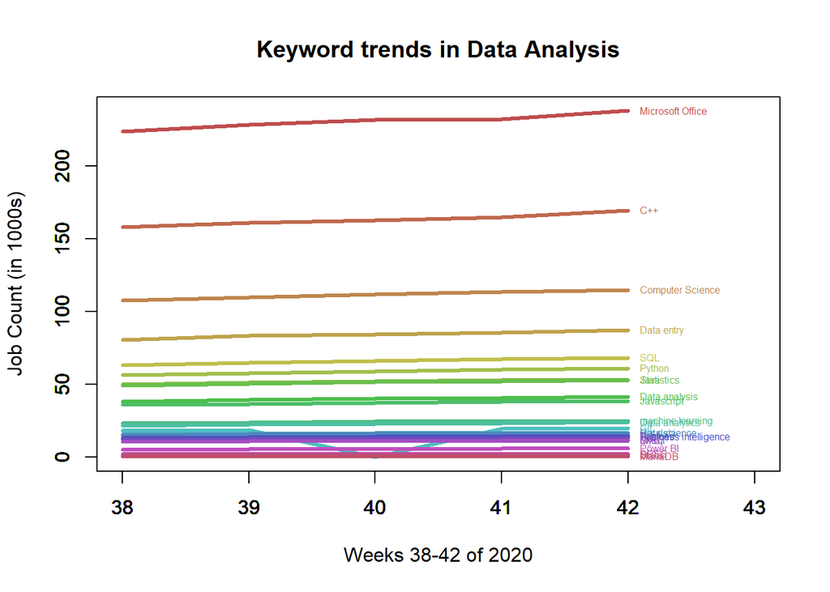

```r
jobs.subset$year.week = as.numeric( gsub("-",".",jobs.subset$year.week, fixed=TRUE) );


jobs.subset = sortDataFrameByNumericColumns(jobs.subset, c("year.week","job.count"), c("ASC","DESC") );
# easier to manage as "how many thousand jobs"
jobs.subset$job.count.k = jobs.subset$job.count / 1000;

do.nothing = plotJobs(jobs.subset);
```

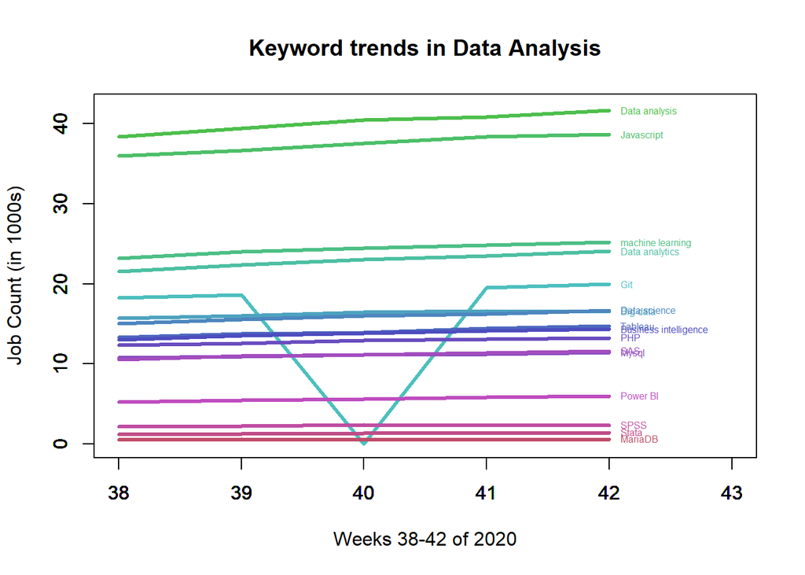

```r
do.nothing = plotJobs(jobs.subset, myy.lim = c(0,42) );
```

#### Initial Perspective

```
-- WRITE SOMETHING HERE --
```

[What is your initial “perspective” of this data, now that you see it? Why are the lines “parallel-ish”? What kind of a trend is that?

Now comment on the line of data for “Data analysis”. How is it trending? How does it compare to other Search-Query Words?

What is your first perspective?

]

#### Missing Data “Git” Week 40?

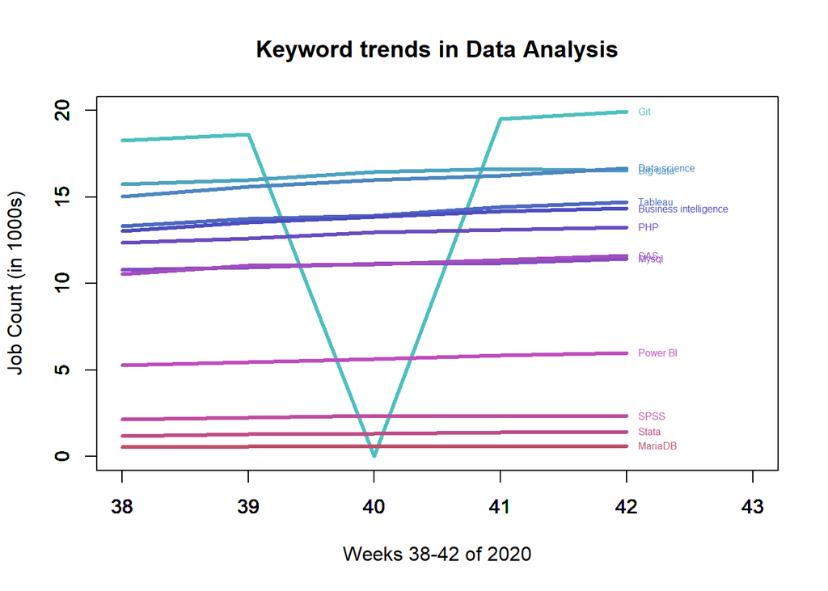

```r
do.nothing = plotJobs(jobs.subset, myy.lim = c(0,20) );
```

**Git-40/Git-41 data history, notice the date-time and file sizes …**

[figure not shown]

**Source: Data provenance history**

[figure not shown]

**Source: Data provenance history**

```
-- WRITE SOMETHING HERE --
```

[Is this data missing or did it just drop to zero that week? How does this relate to the other data (remember the idea of “continuity” in mathematics)? What should you do about it?]

```r
idxs.week.40 = which(jobs.subset$year.week == 2020.40);
idxs.Git     = which(jobs.subset$search.query == "Git");

# set notation
my.idx = intersect(idxs.Git,idxs.week.40);

jobs.subset[idxs.Git,];
```

|  | year.week | search.query | job.count | job.count.k |
| --- | --- | --- | --- | --- |
| 30 | 2020.38 | Git | 18270 | 18.270 |
| 211 | 2020.39 | Git | 18617 | 18.617 |
| 542 | 2020.40 | Git | 0 | 0.000 |
| 573 | 2020.41 | Git | 19528 | 19.528 |
| 753 | 2020.42 | Git | 19945 | 19.945 |

```r
jobs.subset[my.idx,];
```

|  | year.week | search.query | job.count | job.count.k |
| --- | --- | --- | --- | --- |
| 542 | 2020.4 | Git | 0 | 0 |

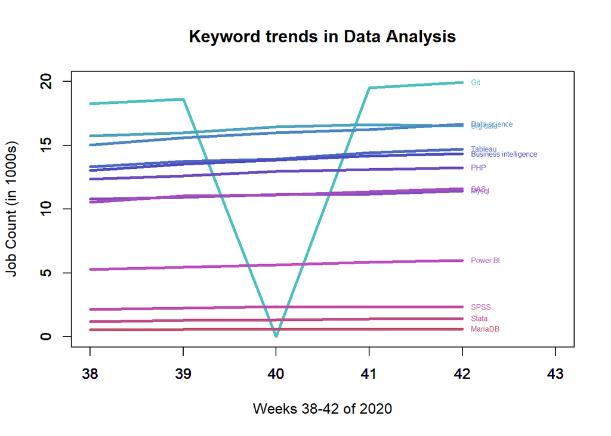

```r
## change this if you feel appropriate?  To what number?
jobs.subset[my.idx,3] = 0;         # job.count
jobs.subset[my.idx,3] = 0/1000;    # job.count.k (in thousands) ...

do.nothing = plotJobs(jobs.subset, myy.lim = c(0,20) );
```

#### Is “Microsoft Office” bigger than “C++”?

I use the term “bigger” or “better” intentionally. We are comparing two items, and these are generic ways of communicating such a comparison. In context of this data problem, a formalized form of the question would be something like: “Utilizing job count for a given search query, determine if the query ‘Microsoft Office’ has a larger job count than the query ‘C++’?” This question will need to be formalized if we are trying to draw specific conclusions, but the initiation of analysis “which is bigger” allows us to understand what the data says or does not say, through exploration.

To answer the question:

Mathematically, if two lines are parallel, and one is above the other, can we use **distance** to draw a conclusion? Now, many times in statistics we deal with noise in the data, it is not “deterministic” but “stochastic” … so we need to understand the variability. Based on the data we see, can we not use “parallel-line” logic to conclude that they are different? This is one dimension of EDA, use mathematics. (“mathematics”)

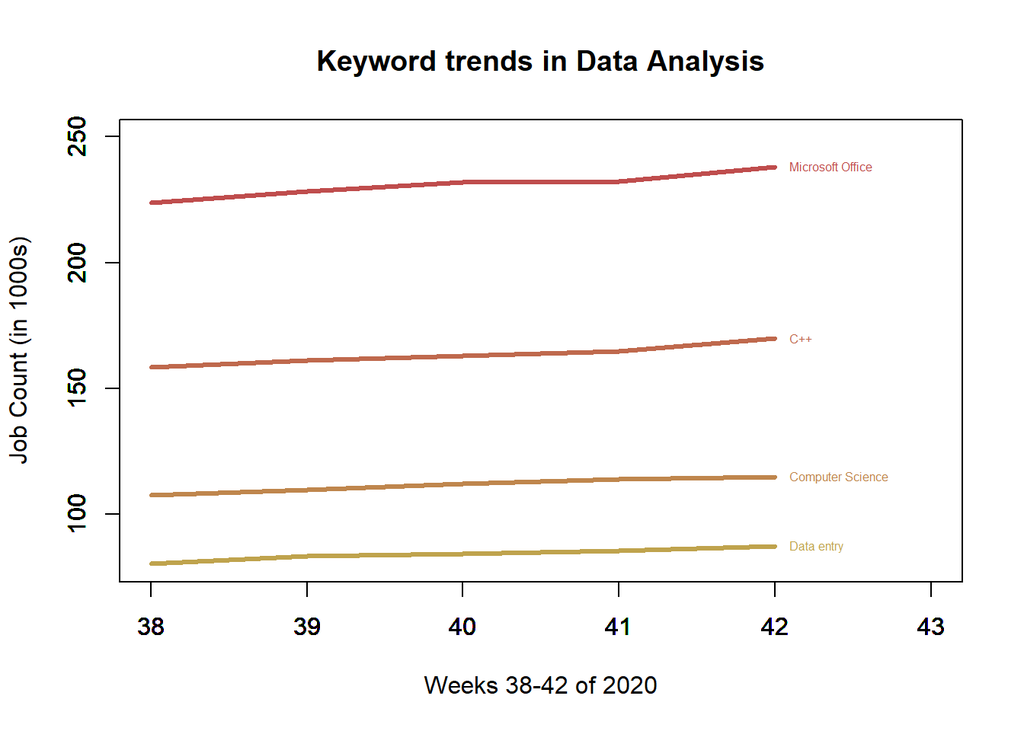

```r
do.nothing = plotJobs(jobs.subset, myy.lim = c(80,250) );
```

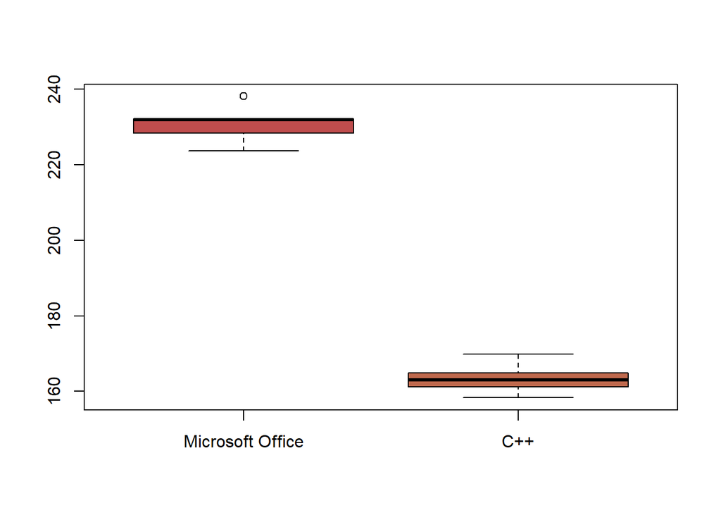

```r
boxplotJobQueryComparison(jobs.subset, "Microsoft Office", "C++");
```

Tukey invented the boxplot as a nice EDA representation of the data. What logical inference can we make about the distances between the boxplots and the fact that no data is overlapping. This is another dimension of EDA, use “distance” and the boxplot “IQR” to compare two elements. What conclusion would we make? (“boxplot”)

```
-- WRITE SOMETHING HERE --
```

[Can we conclude the data are different based on “mathematics” or “boxplot”?

Would a formal “inferential statistical test” tell us something different than logical inference?

How do you think “formal tests” were derived if not from “mathematics” and “boxplot” (EDA)?]

```r
# courage in trusting your intuition may require a fall-back ... for those that need it ...

t.test.jobs(jobs.subset, "Microsoft Office", "C++");
```

```
##
##  Welch Two Sample t-test
##
## data:  x and y
## t = 22.016, df = 7.6613, p-value = 0.00000003332
## alternative hypothesis: true difference in means is not equal to 0
## 95 percent confidence interval:
##  60.31098 74.54582
## sample estimates:
## mean of x mean of y
##  230.8730  163.4446
```

#### Is “Statistics” bigger than “Java”?

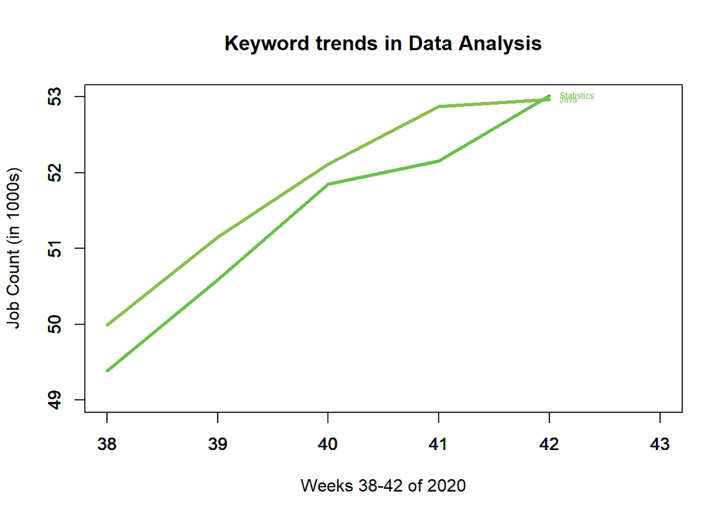

```r
do.nothing = plotJobs(jobs.subset, myy.lim = c(49,53) );
```

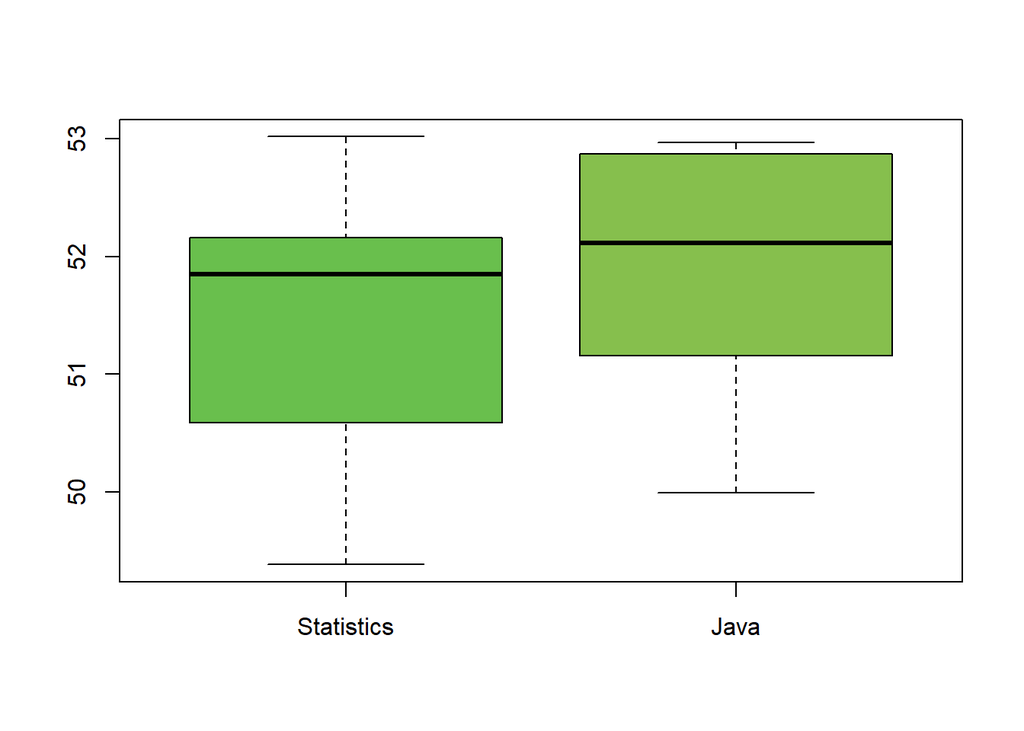

```r
do.nothing = boxplotJobQueryComparison(jobs.subset, "Statistics", "Java");
```

For this data, I can descriptively report that the third-quartile `Q3` of “Statistics” is about equal to the `median` of “Java”. The inter-quartile range (`IQR`) of each overlap. The minimum value of “Java” is larger than the minimum value of “Statistics”. The maximum value of “Java” is slightly smaller than the maximum value of “Statistics”.

```
-- WRITE SOMETHING HERE --
```

[Use “mathematics” and “boxplot” and “ttest” to answer the question: Is “Statistics” bigger than “Java”?]

#### What about “Data science” and “Big data”?

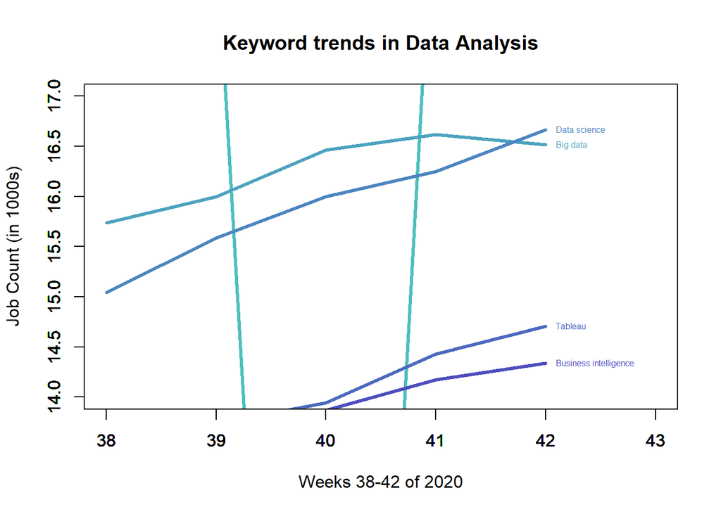

```r
do.nothing = plotJobs(jobs.subset, myy.lim = c(14,17) );
```

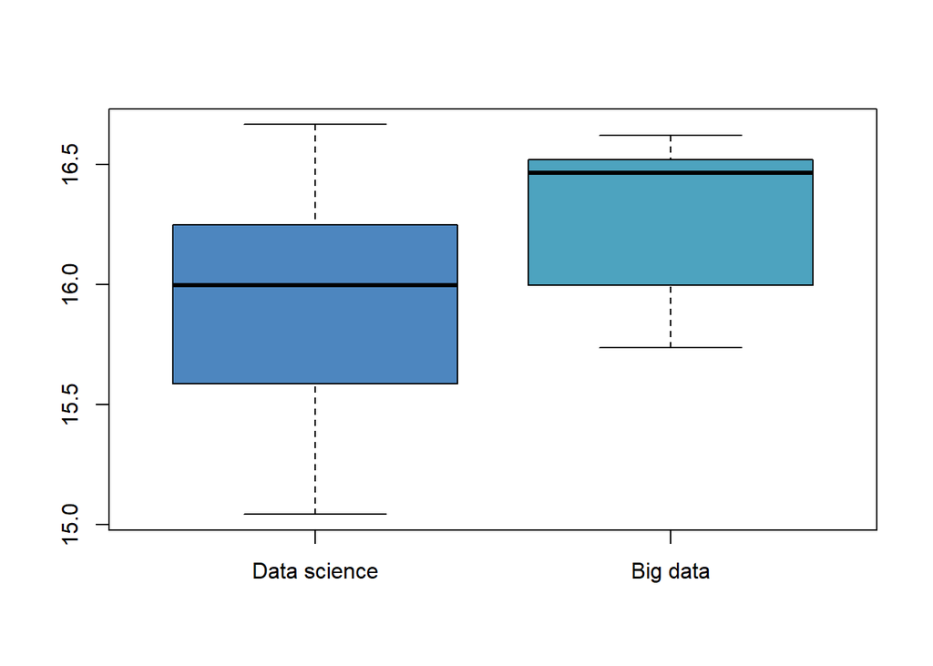

```
-- WRITE SOMETHING HERE --
```

```r
boxplotJobQueryComparison(jobs.subset, "Data science", "Big data");
```

[Use “mathematics” and “boxplot” and “ttest” to make a conclusion.

Next, think carefully about the nature of the data. Is the “collection-approach” flawed to make a conclusion comparing job-counts of these specific keywords? How likely is it that a single-job posting may have both keywords?

This is an example where “data-integrity” knowledge would surpass the other three logical conclusions.

This intuition requires an understanding of what mathematicians call “set theory”. If I am doing an independent search on keywords, is it possible that one job would show up in multiple searches. That is, being counted twice or more.

Intuition and logic would also allow us to conclude that our other comparisons are “very likely okay”. Why?

What would be an improved approach to collecting the data that would allow me to more accurately compare these two keywords?

This is representative of why exploratory data analysis is essential. It provides us insight into the domain and highlights the need for better data, if we can find it.

]

### Conclusions on logical inference

Distance is a fundamental unit of comparison. We can use our “mathematical” understanding of distance. We can use an “EDA” understanding of the data (e.g., the boxplot). We need to understand the data sourcing and how that will relate to the logical conclusions we are trying to draw.

When we transition to “confirmatory inferential statistics”, we cannot leave our understanding of “maths” and “EDA” behind. They are the foundation from which “inferential statistics” is built. They are “logical inference”.

## COMPUTING DISTANCES

If you recall, we had a notebook on collecting data from Wikipedia. We documented the “data-provenance” protocols to make this happen. We have documented and can replicate our data-collection strategies.

### (10 points) Data Provenance defined

Imagine you are preparing for a job interview. Write a 90-second blurb describing “what is data provenance” and “why it matters”. I would suggest the STAR(S) approach mentioned in one of the notebooks. Reference the “Wikipedia” project as an example of how one can implement the features.

```
-- WRITE SOMETHING HERE --
```

[What is data provenance?

Probably about 200-250 words (with the 90 second limit) ]

### Geospatial distances

“Geo-spatial” studies are becoming much more common in the “data analytics” community, so let’s use basic “latitude/longitude” data to formally talk about “distance.”

So we will look at the 50 state capitals of America (USA). Before that, let’s examine some basic principles of distances using my hometown.

### (5 points) Distance from one input to multiple outputs

#### My Hometown “Columbia Falls, Montana” `cfalls`

- Find all ZIP codes within 22 miles of Columbia Falls, MT `cfalls` (use lat/long provide from the Wikipedia lookup)… build the bounding “box” and perform the post-hoc “radial distance” computations (as we did in the homework).

```r
# copy/paste __student_access__/_SECRET_/_SECRET_database_.txt into console...  or this won't work

cfalls.latitude = 48.37028;
cfalls.longitude = -114.18889;
my.radius = 22; my.units = "mi"; #miles

# THIS is where these exam functions live ...
# source_url( paste0(path.github,"misc/functions-midterm-F2000.R") );  # should be 2020 ... oh well




cfalls.info = getNeighborsFromLatLong(22, 48.37028, -114.18889, "mi");
```

```
## [1] "The QUERY returned ...  13  ... NEIGHBORS"
```

```r
cfalls.info$neighbors;
```

| zipcode | latitude | longitude | city | state_long | state |
| --- | --- | --- | --- | --- | --- |
| 59901 | 48.21124 | -114.2939 | KALISPELL | MONTANA | MT |
| 59903 | 48.19303 | -114.3579 | KALISPELL | MONTANA | MT |
| 59904 | 48.19452 | -114.3123 | KALISPELL | MONTANA | MT |
| 59912 | 48.36531 | -114.1927 | COLUMBIA FALLS | MONTANA | MT |
| 59913 | 48.43674 | -114.0507 | CORAM | MONTANA | MT |
| 59916 | 48.61750 | -113.9095 | ESSEX | MONTANA | MT |
| 59919 | 48.38969 | -114.0630 | HUNGRY HORSE | MONTANA | MT |
| 59920 | 48.06516 | -114.5023 | KILA | MONTANA | MT |
| 59921 | 48.62189 | -113.8739 | LAKE MC DONALD | MONTANA | MT |
| 59926 | 48.39134 | -114.0393 | MARTIN CITY | MONTANA | MT |

[output cut: 3 more lines]

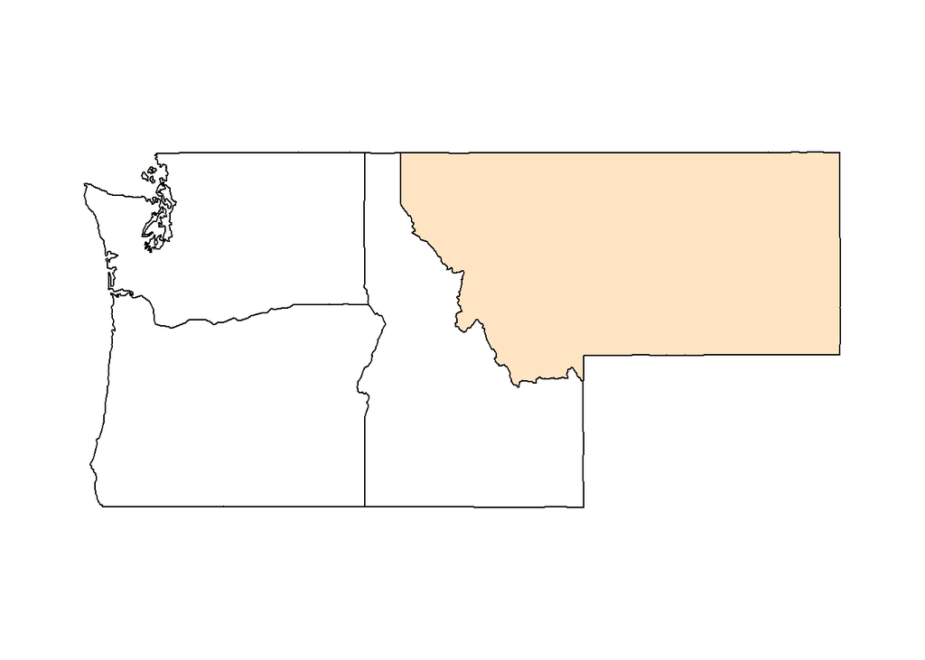

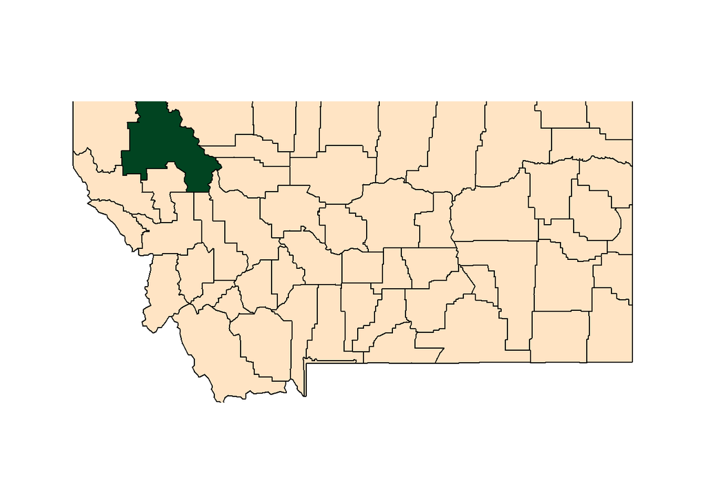

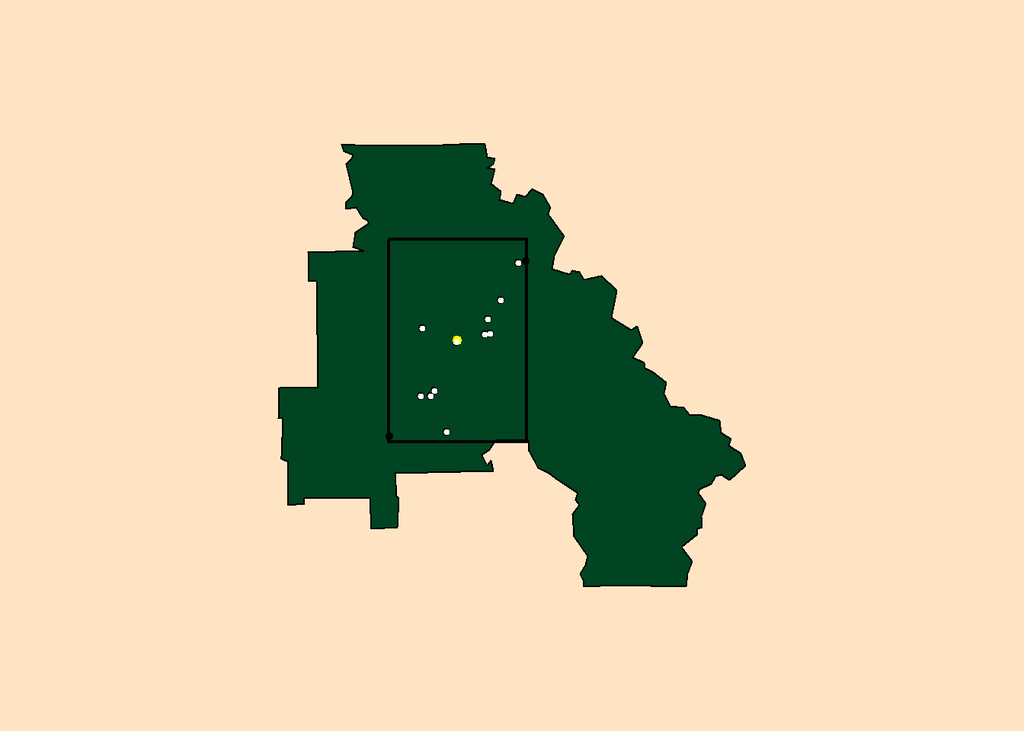

```
-- WRITE SOMETHING HERE --
```

```r
############## plotting ##############
brown = "#ffe4c4";
green = "#014421";

my.state = "montana";
my.state.color = "#ffe4c4";

my.county = "flathead";
my.county.color = "#014421";

my.nearby.states = c("idaho", "washington", "oregon");


plotNeighbors(cfalls.info,
                    state          = my.state,
                    state.color    = my.state.color,
                    state.border   = 0.05,
                    county         = my.county,
                    county.border   = 0.05,  # if you don't see the box, increase this to like 0.75
                    county.color   = my.county.color,
                    nearby.states  = my.nearby.states);
```

[ - why is the box not a square, but a rectangle? … see `factor.lat` and `factor.long` in function `buildBoundingBoxFromRadiusAndGivenLatitudeLongitude` - critique the visualization … what do you like? what would make it better?]

#### Your Hometown of something like it

Instead of `cfalls.info`, you do `hometown.info`

- a location in the continental US of your choosing (not in Montana, Alaska, or Hawaii). [Graphing will not work for Alaska/Hawaii, Alaska has “boroughs” not counties.]
- find the latitude/longitude of the location you have selected (how and where to look that up?)
- Initially start with a radius of `13 miles`
- When you run the code, note how many total “neighbors”; if it is less than 20; increase the “miles” so at least 20 results are returned.
- In the end, you should select a location and radius that works for you. And its visualization also works.
- Be certain to review and update the parameters before calling these functions.

```
hometown.latitude = 00.00000; hometown.longitude = -000.00000; my.radius = 13; my.units = “mi”; #miles hometown.info = getNeighborsFromLatLong( ???? ); plotNeighbors(hometown.info, ????); # you are going to have to change some of these parameters …

hometown.latitude = 00.000;
hometown.longitude = -000.000;
my.radius = 13; my.units = "mi"; #miles


# hometown.info = getNeighborsFromLatLong( ???? );
# hometown.info$neighbors;
# plotNeighbors(hometown.info, ????);  # you are going to have to change some of these parameters ...
```

### U.S. State Capitals (cities)

From Wikipedia, we grabbed one page that listed the 50 U.S. cities that are designated the capitals of each individual state in America (United States of America).

Using the power of a `for-loop` we make our functions work for us. We now have the data ready to go.

```r
capitals = utils::read.csv( paste0(path.mshaffer, "_data_/state-capitals/final/state-capitals.txt"), header=TRUE, quote="", sep="|");

colnames(capitals) = c("state", "capital", "latitude", "longitude", "capital.since", "area.sq.miles", "population.2019.est", "population.2019.est.MSA", "population.2019.est.CSA", "city.rank.in.state", "url");

# hack-add from https://en.wikipedia.org/wiki/ISO_3166-2:US
# TODO, grab this table "appropriately" as a new function
# Is there a dictionary for shortened city names?
# the long-field names is also an issue that needs to be improved upon in the next iteration.

capitals$st = c("AL","AK","AZ","AR","CA","CO","CT","DE","FL","GA","HI","ID","IL","IN","IA","KS","KY","LA","ME","MD","MA","MI","MN","MS","MO","MT","NE","NV","NH","NJ","NM","NY","NC","ND","OH","OK","OR","PA","RI","SC","SD","TN","TX","UT","VT","VA","WA","WV","WI","WY"); # ,"DC","AS","GU","MP","PR","UM","VI");

myLabels = paste0(capitals$capital, ", ", capitals$st);

capitals;
```

| state | capital | latitude | longitude | capital.since | area.sq.miles | population.2019.est | population.2019.est.MSA | population.2019.est.CSA | city.rank.in.state | url | st |
| --- | --- | --- | --- | --- | --- | --- | --- | --- | --- | --- | --- |
| Alabama | Montgomery | 32.36167 | -86.27917 | 1846 | 159.80 | 198525 | 373290 | 461516 | 2 | https://en.wikipedia.org/wiki/Montgomery,_Alabama | AL |
| Alaska | Juneau | 58.30000 | -134.41600 | 1906 | 2716.70 | 32113 | 32113 | NA | 3 | https://en.wikipedia.org/wiki/Juneau,_Alaska | AK |
| Arizona | Phoenix | 33.45000 | -112.06700 | 1912 | 517.60 | 1680992 | 4948203 | 5002221 | 1 | https://en.wikipedia.org/wiki/Phoenix,_Arizona | AZ |
| Arkansas | Little Rock | 34.73611 | -92.33111 | 1821 | 116.20 | 197312 | 742384 | 908941 | 1 | https://en.wikipedia.org/wiki/Little_Rock,_Arkansas | AR |
| California | Sacramento | 38.58167 | -121.49444 | 1854 | 97.90 | 513624 | 2363730 | 2639124 | 6 | https://en.wikipedia.org/wiki/Sacramento,_California | CA |
| Colorado | Denver | 39.73917 | -104.99028 | 1867 | 153.30 | 727211 | 2967239 | 3617927 | 1 | https://en.wikipedia.org/wiki/Denver | CO |
| Connecticut | Hartford | 41.76250 | -72.67417 | 1875 | 17.30 | 122105 | 1204877 | 1470083 | 3 | https://en.wikipedia.org/wiki/Hartford,_Connecticut | CT |
| Delaware | Dover | 39.15806 | -75.52444 | 1777 | 22.40 | 38079 | 180786 | 7209620 | 2 | https://en.wikipedia.org/wiki/Dover,_Delaware | DE |
| Florida | Tallahassee | 30.45500 | -84.25333 | 1824 | 95.70 | 194500 | 387227 | NA | 7 | https://en.wikipedia.org/wiki/Tallahassee,_Florida | FL |
| Georgia | Atlanta | 33.75500 | -84.39000 | 1868 | 133.50 | 506811 | 6020364 | 6853392 | 1 | https://en.wikipedia.org/wiki/Atlanta | GA |

[output cut: 40 more lines]

#### Initial Plotting

- Plot the data on `usmap` (ggplot2)

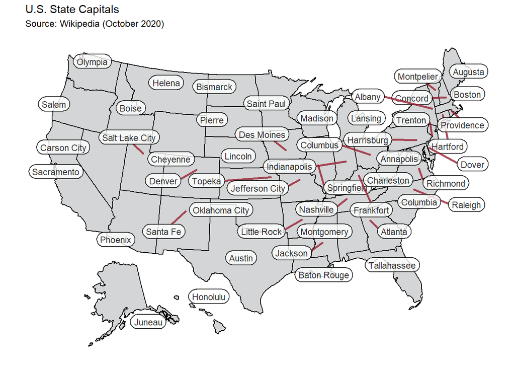

```r
latlong = removeAllColumnsBut(capitals,c( "state", "st", "capital", "latitude", "longitude", "population.2019.est") );

# first two elements have to be this
latlong = moveColumnsInDataFrame(latlong, c("longitude","latitude"), "before", "state");

# for transform to work
library(usmap);
latlong.transform = usmap_transform(latlong);
library(ggplot2);

### plot_usmap ...

plot_usmap(fill = "#53565A", alpha = 0.25) +
  ggrepel::geom_label_repel(data = latlong.transform,
             aes(x = longitude.1, y = latitude.1, label = capital),
             size = 3, alpha = 0.8,
             label.r = unit(0.5, "lines"), label.size = 0.5,
             segment.color = "#981E32", segment.size = 1,
             seed = 1002) +
  scale_size_continuous(range = c(1, 16),
                        label = scales::comma) +
  labs(title = "U.S. State Capitals",
       subtitle = "Source: Wikipedia (October 2020)") +
  theme(legend.position = "right")
```

- Plot the data using maths `voronoi` (tripack)

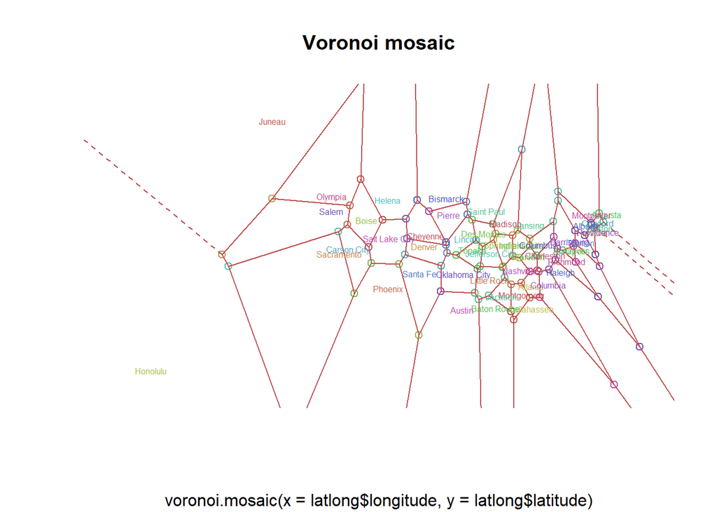

```r
colors = rainbow(50, s = 0.6, v = 0.75);

## initial visualization ...
library(tripack);
# plot( voronoi.mosaic(latlong[,4:3], duplicate="remove"), col=colors, xlab="");
plot( voronoi.mosaic(x = latlong$longitude, y = latlong$latitude), col=colors, xlab="");
text(x = latlong$longitude, y = latlong$latitude, labels = latlong$capital, col=colors, cex=0.5);
```

- Plot the data on `map` (base)

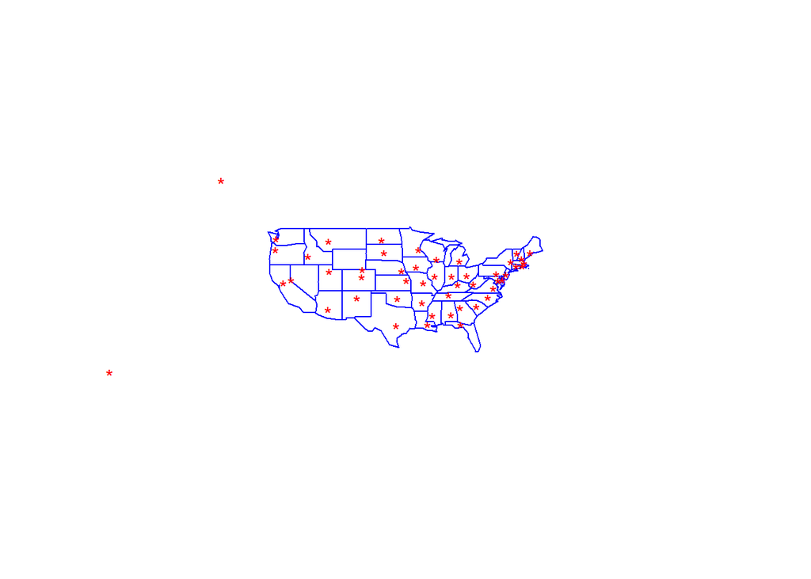

```r
### how is any of the other visualizations really any better than a simple map ... with actual locations for Alaska/Hawaii?
library(maps);
map('state', plot = TRUE, fill = FALSE,
    col = "blue", myborder = 0.5
    );
points(x = latlong$longitude, y = latlong$latitude,
                  col = "red", pch = "*", cex = 1);
```

#### (5 points) Comparing “Visualization Options”

Above, the data was displayed using three different visualization packages.

The first `plot_usmap` uses the ``ggplot2` methodology which is tied to the “tidyverse” landscape of the `R` community.

The second `voronoi.mosaic` uses the graph-theory topology known as Voroni partitioning https://en.wikipedia.org/wiki/Voronoi_diagram with the “base” plot function to visualize the topology.

The last one `map` is from the “base” environment.

```
-- WRITE SOMETHING HERE --
```

[ Visually, which is the most appealing to you? Why?

Functionally, which presents the data most effectively? Why?

When we create visualizations, it is essential to portray the data accurately. For example, there are times when putting Alaska/Hawaii next to California might be appropriate, and other times it might not be.

What is a one key factor that would determine this appropriateness?

]

#### (5 points) Building the distance matrix

The dataframe we are using has been named `latlong` to represent the latitudes and longitudes of the 50 U.S. cities in America.

```r
# manual conversion
# how many miles is 1 degree of latitude
latitude.factor = 69;  # rough mile estimate  # 68.703 ?
latlong$x.lat = latlong$latitude * latitude.factor;

longitude.factor = 54.6;  # rough mile estimate
latlong$y.long = latlong$longitude * longitude.factor;

latlong = moveColumnsInDataFrame(latlong, c("y.long","x.lat"), "before", "longitude");
```

Let’s start with geo-spatial distances. I will do `distMeeus` and you will do `distHaversine`

##### **Meeus**

These distance formulas can utilize the true geo-spatial coordinates. The distance table is getting large, so there is a helper function to lookup a certain value.

```r
library(geosphere);
library(measurements);


dist.meeus = conv_unit(  distm( latlong[,3:4],
                  fun=distMeeus),  "m", "mi");  # default meters to miles

dist.meeus.m = as.matrix( dist.meeus );
  rownames(dist.meeus.m) =
  colnames(dist.meeus.m) = myLabels;

dist.meeus.df = as.data.frame( round( dist.meeus.m, digits=1) );

dist.meeus.df;  ## too big
```

|  | Montgomery, AL | Juneau, AK | Phoenix, AZ | Little Rock, AR | Sacramento, CA | Denver, CO | Hartford, CT | Dover, DE | Tallahassee, FL | Atlanta, GA | Honolulu, HI | Boise, ID | Springfield, IL | Indianapolis, IN | Des Moines, IA | Topeka, KS | Frankfort, KY | Baton Rouge, LA | Augusta, ME | Annapolis, MD | Boston, MA | Lansing, MI | Saint Paul, MN | Jackson, MS | Jefferson City, MO | Helena, MT | Lincoln, NE | Carson City, NV | Concord, NH | … |
| --- | --- | --- | --- | --- | --- | --- | --- | --- | --- | --- | --- | --- | --- | --- | --- | --- | --- | --- | --- | --- | --- | --- | --- | --- | --- | --- | --- | --- | --- | --- |
| Montgomery, AL | 0.0 | 2855.6 | 1497.1 | 385.6 | 2018.8 | 1161.4 | 990.5 | 763.8 | 177.7 | 145.7 | 4408.0 | 1795.1 | 546.4 | 510.7 | 754.3 | 701.4 | 410.3 | 318.1 | 1213.3 | 713.6 | 1081.8 | 721.6 | 942.1 | 228.5 | 542.0 | 1677.8 | 819.6 | 1927.5 | 1097.1 | … |
| Juneau, AK | 2855.6 | 0.0 | 2005.8 | 2516.3 | 1480.3 | 1825.6 | 2855.1 | 2881.2 | 3032.3 | 2845.3 | 2809.0 | 1280.7 | 2338.4 | 2464.8 | 2106.8 | 2167.1 | 2591.8 | 2796.7 | 2836.7 | 2855.0 | 2884.4 | 2375.7 | 1961.5 | 2725.0 | 2313.6 | 1234.8 | 2040.7 | 1474.7 | 2826.1 | … |
| Phoenix, AZ | 1497.1 | 2005.8 | 0.0 | 1133.4 | 635.1 | 585.2 | 2215.2 | 2062.7 | 1642.0 | 1591.5 | 2910.9 | 735.9 | 1316.1 | 1498.7 | 1154.9 | 991.0 | 1556.0 | 1242.3 | 2370.3 | 2010.2 | 2299.3 | 1621.6 | 1285.2 | 1272.6 | 1166.3 | 906.7 | 987.5 | 582.6 | 2277.8 | … |
| Little Rock, AR | 385.6 | 2516.3 | 1133.4 | 0.0 | 1634.7 | 777.6 | 1170.3 | 977.2 | 555.6 | 459.4 | 4040.4 | 1413.7 | 379.0 | 485.8 | 478.0 | 351.1 | 479.2 | 303.1 | 1367.5 | 923.1 | 1261.7 | 693.0 | 705.4 | 208.7 | 265.0 | 1312.5 | 481.6 | 1542.6 | 1258.1 | … |
| Sacramento, CA | 2018.8 | 1480.3 | 635.1 | 1634.7 | 0.0 | 888.7 | 2558.5 | 2452.1 | 2181.2 | 2086.5 | 2461.8 | 443.7 | 1702.3 | 1886.8 | 1485.1 | 1388.2 | 1975.1 | 1808.7 | 2669.3 | 2404.2 | 2631.2 | 1946.8 | 1522.9 | 1809.3 | 1580.7 | 733.2 | 1327.0 | 101.5 | 2596.2 | … |
| Denver, CO | 1161.4 | 1825.6 | 585.2 | 777.6 | 888.7 | 0.0 | 1691.6 | 1569.4 | 1333.2 | 1211.9 | 3343.9 | 638.1 | 815.5 | 1001.0 | 610.4 | 499.8 | 1086.5 | 1009.1 | 1824.8 | 1520.3 | 1769.7 | 1082.0 | 706.2 | 973.2 | 692.4 | 591.0 | 445.2 | 790.4 | 1740.9 | … |
| Hartford, CT | 990.5 | 2855.1 | 2215.2 | 1170.3 | 2558.5 | 1691.6 | 0.0 | 234.2 | 1011.7 | 845.0 | 5018.8 | 2194.7 | 899.4 | 719.9 | 1081.2 | 1224.4 | 691.5 | 1291.6 | 228.9 | 278.9 | 92.5 | 612.0 | 1048.8 | 1163.9 | 1052.8 | 1962.3 | 1247.2 | 2457.2 | 115.3 | … |
| Dover, DE | 763.8 | 2881.2 | 2062.7 | 977.2 | 2452.1 | 1569.4 | 234.2 | 0.0 | 777.8 | 618.1 | 4912.6 | 2114.9 | 756.0 | 569.8 | 967.7 | 1081.6 | 509.2 | 1071.2 | 463.1 | 54.1 | 321.7 | 532.2 | 985.4 | 948.4 | 897.5 | 1903.8 | 1125.8 | 2351.7 | 348.1 | … |
| Tallahassee, FL | 177.7 | 3032.3 | 1642.0 | 555.6 | 2181.2 | 1333.2 | 1011.7 | 777.8 | 0.0 | 227.5 | 4549.8 | 1968.8 | 712.8 | 651.0 | 928.6 | 878.9 | 535.0 | 413.2 | 1240.0 | 733.8 | 1099.1 | 846.8 | 1108.9 | 372.8 | 718.8 | 1855.1 | 997.3 | 2091.5 | 1124.2 | … |
| Atlanta, GA | 145.7 | 2845.3 | 1591.5 | 459.4 | 2086.5 | 1211.9 | 845.0 | 618.1 | 227.5 | 0.0 | 4499.8 | 1835.5 | 508.7 | 426.1 | 739.4 | 727.3 | 307.6 | 458.6 | 1068.5 | 567.9 | 936.2 | 619.3 | 900.5 | 351.0 | 547.3 | 1696.3 | 832.4 | 1992.4 | 952.1 | … |

[output cut: 40 more lines]

```r
lookupPairwiseValue(dist.meeus.df, "Juneau, AK", "Montgomery, AL");
```

```
## [1] 2855.6
```

##### **Haversine**

You can compare the two with the code below (currently in comments).

```r
#
# x = dist.meeus.df[,2]; # Juneau ... pick one location
# y = dist.haversine.df[,2];
#
# my.lim = c(0, 4000 );
#
# plot(x, y,
#             xlab="Meeus",
#             ylab="Haversine",
#             main="dist( Juneau, AK )",
#             xlim=my.lim,
#             ylim=my.lim);
#
# plotXYwithBoxPlots(x, y,
#             xlab="Meeus",
#             ylab="Haversine",
#             main="dist( Juneau, AK )",
#             xlim=my.lim,
#             ylim=my.lim);
```

```
-- WRITE SOMETHING HERE --
```

[ Examining the data above, is there much difference between these two calculations?

What is the conceptual difference between these two calculations? Try `?distMeeus` or `?distHaversine`

Are the results similar?

Is there a more accurate distance algorithm for geo-spatial calculations? If so, what is it?

]

Let’s now do `manhattan` and `euclidean` which are more common in the “statistical clustering” domain. I will do `euclidean`.

##### **Euclidean**

We have converted the true latitude/longitude to a miles-type format, so the resulting table will report miles.

```r
dist.euclidean = dist( latlong[,1:2],
                      method="euclidean", diag=TRUE, upper=TRUE);
dist.euclidean.m = as.matrix( dist.euclidean );
  rownames(dist.euclidean.m) =
  colnames(dist.euclidean.m) = myLabels;

dist.euclidean.df = as.data.frame( round( dist.euclidean.m, digits=1) );

dist.euclidean.df;  ## too big
```

|  | Montgomery, AL | Juneau, AK | Phoenix, AZ | Little Rock, AR | Sacramento, CA | Denver, CO | Hartford, CT | Dover, DE | Tallahassee, FL | Atlanta, GA | Honolulu, HI | Boise, ID | Springfield, IL | Indianapolis, IN | Des Moines, IA | Topeka, KS | Frankfort, KY | Baton Rouge, LA | Augusta, ME | Annapolis, MD | Boston, MA | Lansing, MI | Saint Paul, MN | Jackson, MS | Jefferson City, MO | Helena, MT | Lincoln, NE | Carson City, NV | Concord, NH | … |
| --- | --- | --- | --- | --- | --- | --- | --- | --- | --- | --- | --- | --- | --- | --- | --- | --- | --- | --- | --- | --- | --- | --- | --- | --- | --- | --- | --- | --- | --- | --- |
| Montgomery, AL | 0.0 | 3179.8 | 1410.0 | 368.8 | 1970.1 | 1141.4 | 986.2 | 751.5 | 171.9 | 141.0 | 3982.0 | 1808.9 | 545.3 | 511.1 | 752.5 | 690.9 | 410.2 | 298.3 | 1221.2 | 702.2 | 1079.8 | 721.9 | 944.6 | 213.3 | 536.2 | 1714.4 | 813.7 | 1887.7 | 1099.0 | … |
| Juneau, AK | 3179.8 | 0.0 | 2104.5 | 2814.9 | 1532.6 | 2054.6 | 3559.0 | 3476.2 | 3345.6 | 3213.9 | 2855.5 | 1419.7 | 2757.3 | 2928.8 | 2508.1 | 2496.8 | 3040.2 | 3044.1 | 3658.8 | 3431.8 | 3629.7 | 2927.1 | 2437.2 | 3008.5 | 2678.0 | 1465.6 | 2387.9 | 1543.7 | 3587.6 | … |
| Phoenix, AZ | 1410.0 | 2104.5 | 0.0 | 1081.2 | 624.8 | 581.0 | 2226.0 | 2033.7 | 1532.6 | 1511.3 | 2636.9 | 736.9 | 1299.8 | 1480.3 | 1153.2 | 974.3 | 1520.9 | 1159.2 | 2427.5 | 1978.9 | 2321.6 | 1633.5 | 1304.7 | 1197.4 | 1142.3 | 906.7 | 981.7 | 576.4 | 2313.0 | … |
| Little Rock, AR | 368.8 | 2814.9 | 1081.2 | 0.0 | 1614.3 | 772.6 | 1177.7 | 967.0 | 530.8 | 438.8 | 3695.8 | 1440.2 | 378.7 | 483.9 | 478.2 | 349.9 | 472.5 | 302.5 | 1397.4 | 912.4 | 1274.7 | 696.5 | 705.6 | 205.0 | 265.1 | 1350.9 | 481.6 | 1528.8 | 1276.9 | … |
| Sacramento, CA | 1970.1 | 1532.6 | 624.8 | 1614.3 | 0.0 | 904.7 | 2674.6 | 2510.3 | 2109.3 | 2053.1 | 2315.8 | 451.9 | 1740.5 | 1931.1 | 1536.0 | 1409.3 | 2000.0 | 1747.8 | 2851.2 | 2456.8 | 2765.8 | 2037.6 | 1611.6 | 1763.6 | 1600.9 | 757.0 | 1363.6 | 102.5 | 2746.2 | … |
| Denver, CO | 1141.4 | 2054.6 | 581.0 | 772.6 | 904.7 | 0.0 | 1770.0 | 1609.3 | 1300.9 | 1198.2 | 3154.4 | 668.0 | 837.3 | 1028.2 | 633.8 | 510.0 | 1103.9 | 989.8 | 1948.2 | 1556.4 | 1861.2 | 1135.2 | 742.2 | 957.6 | 704.4 | 609.0 | 459.8 | 807.8 | 1842.1 | … |
| Hartford, CT | 986.2 | 3559.0 | 2226.0 | 1177.7 | 2674.6 | 1770.0 | 0.0 | 237.7 | 1004.2 | 845.3 | 4860.5 | 2380.0 | 937.0 | 749.0 | 1143.7 | 1270.4 | 709.7 | 1276.8 | 236.4 | 284.1 | 97.1 | 651.7 | 1136.3 | 1157.8 | 1087.1 | 2174.0 | 1312.3 | 2577.5 | 117.4 | … |
| Dover, DE | 751.5 | 3476.2 | 2033.7 | 967.0 | 2510.3 | 1609.3 | 237.7 | 0.0 | 766.7 | 611.0 | 4661.1 | 2242.2 | 772.8 | 582.1 | 1002.2 | 1101.0 | 514.4 | 1044.9 | 474.1 | 54.8 | 328.7 | 550.9 | 1039.0 | 929.9 | 909.9 | 2057.6 | 1160.6 | 2415.6 | 354.1 | … |
| Tallahassee, FL | 171.9 | 3345.6 | 1532.6 | 530.8 | 2109.3 | 1300.9 | 1004.2 | 766.7 | 0.0 | 227.8 | 4068.1 | 1966.6 | 709.0 | 651.0 | 923.0 | 861.4 | 535.5 | 378.1 | 1240.4 | 724.3 | 1092.3 | 847.4 | 1110.2 | 347.9 | 707.9 | 1881.0 | 985.2 | 2030.0 | 1120.8 | … |
| Atlanta, GA | 141.0 | 3213.9 | 1511.3 | 438.8 | 2053.1 | 1198.2 | 845.3 | 611.0 | 227.8 | 0.0 | 4102.3 | 1865.4 | 506.5 | 426.0 | 739.2 | 717.2 | 307.8 | 435.3 | 1080.2 | 561.4 | 939.0 | 619.6 | 906.6 | 332.0 | 539.7 | 1749.4 | 828.9 | 1967.3 | 958.0 | … |

[output cut: 40 more lines]

```r
lookupPairwiseValue(dist.euclidean.df, "Juneau, AK", "Montgomery, AL");
```

```
## [1] 3179.8
```

You can compare the two with the code below (currently in comments).

```r
#
# x = dist.manhattan.df[,2]; # Juneau ... pick one location
# y = dist.euclidean.df[,2];
#
# my.lim = c(0, 4000 );
#
# plot(x, y,
#             xlab="Manhattan",
#             ylab="Euclidean",
#             main="dist( Juneau, AK )",
#             xlim=my.lim,
#             ylim=my.lim);
#
# plotXYwithBoxPlots(x, y,
#             xlab="Manhattan",
#             ylab="Euclidean",
#             main="dist( Juneau, AK )",
#             xlim=my.lim,
#             ylim=my.lim);
```

```
-- WRITE SOMETHING HERE --
```

[ What is the difference between these two calculations?

Are the results similar?

]

## HIERARCHICAL clustering as a function of distance

Aggregating or agglomerating data is typically called “clustering” and is generally considered to be a “unsupervised learning” method.

### Introduction

We use `hclust` to perform Hierarchical Clustering. The word “hierarchical” is used because the nature of the data is organized like a family genealogy. The bottom of the tree represents the descendants that eventually “link” to a common ancestor.

If you type `?hclust` you can review the parameter options which we explored in a notebook. `hclust` is primarily a function of `dist()` [distance], and we have just computed some distances, so we could try and apply `hclust` to our data to see if our state capitals will cluster into meaningful regions.

There are several agglomeration methods (“linkage”) one could choose from. Each method takes the `dist` https://en.wikipedia.org/wiki/Hierarchical_clustering#Metric and performs some pairwise distance algorithm called a linkage criteria https://en.wikipedia.org/wiki/Hierarchical_clustering#Linkage_criteria.

I generally use either the “complete” linkage method or the “ward.D2” linkage method. You can read help `?hclust` to better appreciate why: “A number of different clustering methods are provided. Ward’s minimum variance method aims at finding compact, spherical clusters. The complete linkage method finds similar clusters.”

If you are trying to link binary data (zeroes and ones) or genomic data (where the distances were computed using a genetic-distance algorithm), you may want to try the UPGMA approach: “average” or “centroid”.

### Analogy of Family

Since I am from a large family, I will make a family tree analogy. For me, I am the 5th of 11 siblings (5 brothers, 5 sisters). If I wanted to cluster the siblings in a pair-wise fashion, how would I begin?

First, I would ask, which other sibling is most like me? Since this is a pair-wise approach, and there are 11 siblings, maybe at the initial stage, I will not be paired with another sibling.

In fact, at least one will not be paired because the total number is 11. And maybe more than one will not be paired in the initial stage. Remember “similarity” is being defined based on some distance-linkage method. And to use this approach, “similarity” needs to numerical data.

At each stage, pair-wise joining occurs until there is nothing left to join. The tree contains all of the elements. Every element (branch) eventually joins the main branch (trunk) of the tree.

### Clustering U.S. capital cities based on latitude, longitude

We already have some data for the U.S. capitals and have computed a Euclidean distance using a capital-city’s longitude and latitude. Let’s choose to cut the result into `12` agglomerations. Why 12? It was a choice based on my life experience and intuition. As I reflected on why, I did some external searching that validates a choice in that range https://en.wikipedia.org/wiki/List_of_regions_of_the_United_States. You certainly could run this analysis with another choice It is exploratory, and your intuition matters.

Geographically, I am saying the capital-city does represent the state. An ideal representation may be in the center (centroid) of the state. Remember this when we see the linkages with “New York”, the city is Albany, not Manhattan.

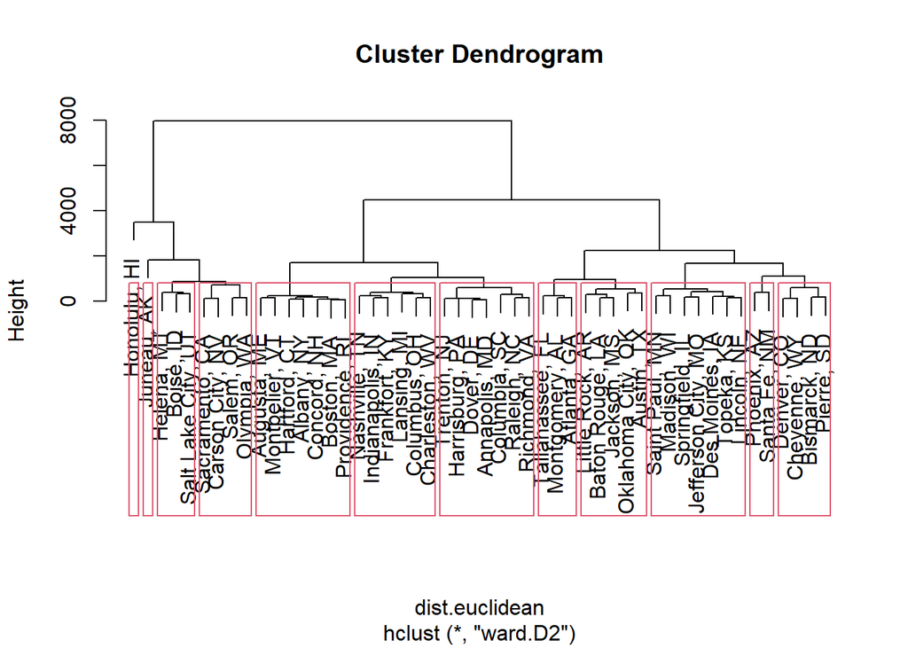

```r
## ward.D2
hclust.ward2.dist.euclidean = hclust(dist.euclidean, method="ward.D2");

plot( hclust.ward2.dist.euclidean,
      labels= myLabels );
rect.hclust( hclust.ward2.dist.euclidean, k=12 );
```

```r
## complete
#
# hclust.complete.dist.euclidean = hclust(dist.euclidean, method="complete");
#
# plot( hclust.ward2.dist.euclidean,
#       labels= myLabels );
# rect.hclust( hclust.ward2.dist.euclidean, k=12 );
#
```

### Understanding the `cutree`

In the above example, the tree was cut into 12 groups based on the “distance” formula used and based on the “agglomeration” linkage technique invoice. I likely should have used a “geo-spatial” distance, but we will see that mere “euclidean” distance seems to perform okay.

A fancy word for this statistical tree is a “dendrogram”. I call each element of the tree a branch. The smallest branches (twigs) are the fundamental elements, in this case the cities. Over time, they merge with other small branches, and so on.

The relative height when this smallest branch merges with another branch demonstrates when the branch has found a similar pair-wise match (with another smallest branch or a merging branch). I call “Honolulu Hawaii” an isolate because the vertical height when it merges with another branch is the highest of all of the smallest branches (e.g., cities). “Juneau Alaska” is another isolate, but it does merge before “Hawaii”.

It would be nice if we could decompose this information and look at one `cutree` at a time. And color-code the distinctions. Using the function `plot.hclust.sub` we can do this.

```r
source_url( paste0(path.github,"humanVerseWSU/R/functions-EDA.R") );  # EDA functions ...
```

```
## SHA-1 hash of file is dd72e464241952b23d5b08d2213099eccf7a86f6
```

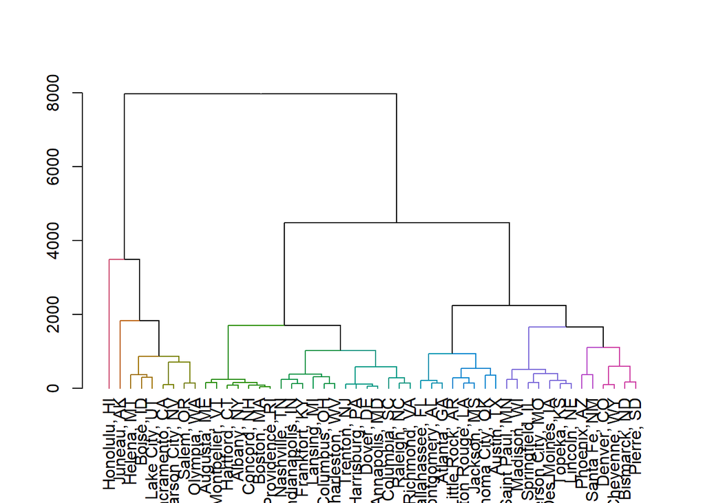

```
## [1] "Pruning 1 of 12"
## [1] "Pruning 2 of 12"
## [1] "Pruning 3 of 12"
## [1] "Pruning 4 of 12"
## [1] "Pruning 5 of 12"
## [1] "Pruning 6 of 12"
## [1] "Pruning 7 of 12"
## [1] "Pruning 8 of 12"
## [1] "Pruning 9 of 12"
## [1] "Pruning 10 of 12"
## [1] "Pruning 11 of 12"
## [1] "Pruning 12 of 12"
```

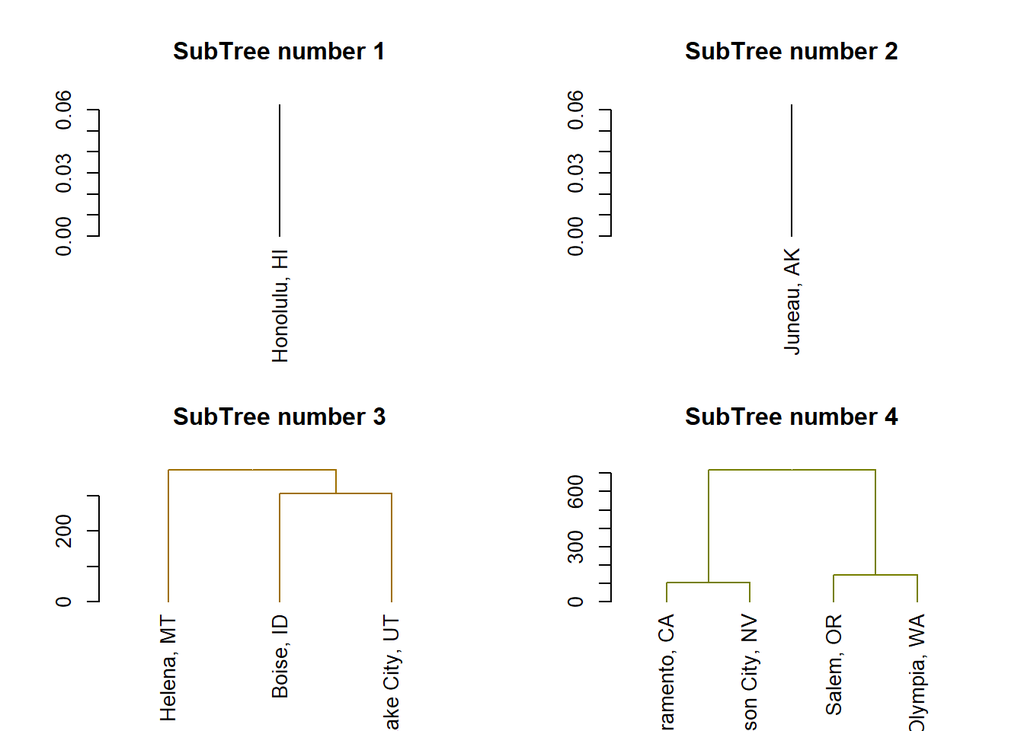

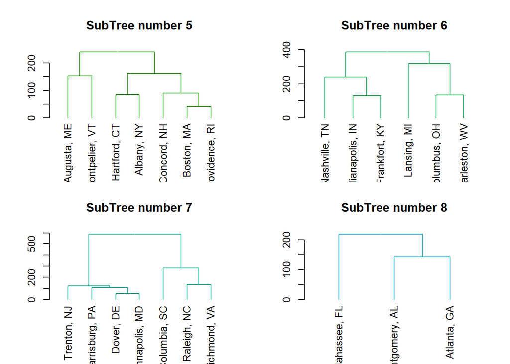

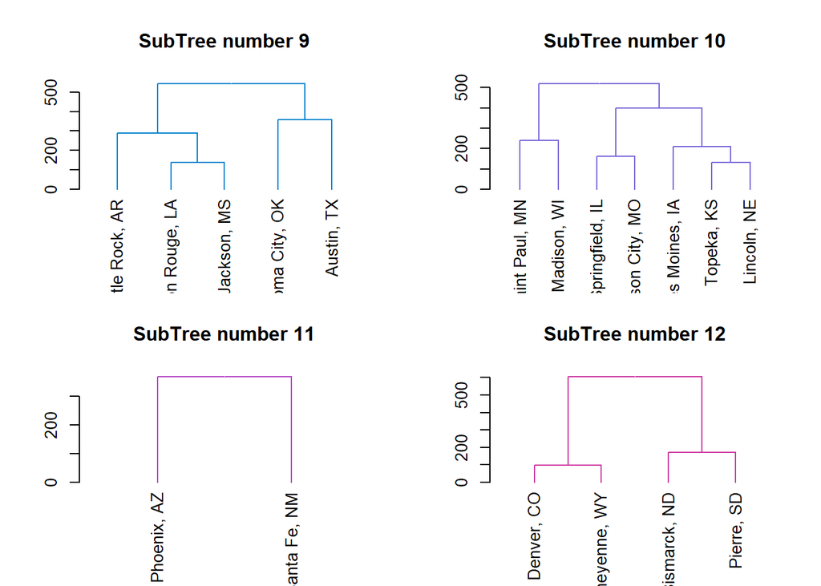

```r
hclust.ward2.dist.euclidean$labels = myLabels;
plot.hclust.sub(hclust.ward2.dist.euclidean, k=12);
```

```r
# plot.hclust.sub(hclust.complete.dist.euclidean, k=12);
```

### (10 points) Review one clustering tree (dendrogram)

Choose either `hclust.ward2.dist.euclidean` or `hclust.complete.dist.euclidean` and review how the U.S. state capitals are clustered. [I commented out one form, so you will have to re-run if you want to select that one.]

Comment on the “face validity” of this approach based on your understanding about how the U.S. regions are defined? Are the North/South Dakotas together? What about the North/South Carolinas? What about the Pacific Northwest? While living in Kentucky, some people called the area “Kentuckiana” meaning Kentucky/Indiana. Does that show up? Also note anything that seems peculiar.

[output not shown]

### Additional remarks about `hclust`

I find `hclust` to be a nice initial perusal of the data.

If you want to understand the stability of a particular `hclust` to use it for something other than an “initial perusal of the data,” I would recommend `pvclust` which I introduced in the weekly notebooks. It is often used in peer-reviewed research, as it provides a `p-value` of sorts regarding the **stability** of the `hclust` structure.

## GENERIC clustering

Aggregating or agglomerating data is typically called “clustering”. In exploration, we can create some generic clustering techniques. Below we will create two adhoc clustering rules.

### Arbitrary Aggregation

Recall the “movie dataset” with “Will Smith” and “Denzel Washington”. We have a collection of movies, and how much money each movie made at the box office. We could organize those movies by some arbitrary rules. For example:

- Cluster 1: NA. We have missing data regarding the money. So let’s put all movies that are NA into that cluster.
- Cluster 2: Under a million dollars
- Cluster 3: 1-4.99… million dollars (greater than or equal to one, but less than 5)
- Cluster 4: 5-49.99…
- Cluster 5: 50+

#### (5 points) Movie Aggregation [Arbitrary] for Will and Denzel

```r
library(devtools);
source_url( paste0(path.mshaffer, "will") );
```

```
## SHA-1 hash of file is 3c1c97d961577e9b47a12faa20dca74bfe755c87
```

```r
source_url( paste0(path.mshaffer, "denzel") );
```

```
## SHA-1 hash of file is 6692d8c5629db1ae023691bb55de2664a48cdde0
```

```r
movies.50 = rbind(will$movies.50, denzel$movies.50);

unique(movies.50$ttid); # are they in any shared movies ???
```

```
##   [1] "tt0480249" "tt1386697" "tt0116629" "tt0119654" "tt0343818" "tt0454921"
##   [7] "tt0448157" "tt0120912" "tt1409024" "tt0386588" "tt0814314" "tt0112442"
##  [13] "tt0172156" "tt0120660" "tt6139732" "tt0145660" "tt2381941" "tt1815862"
##  [19] "tt1596350" "tt1229340" "tt5519340" "tt0307453" "tt1155076" "tt0120891"
##  [25] "tt0120783" "tt1502397" "tt0248667" "tt4682786" "tt3322364" "tt1025100"
##  [31] "tt0114558" "tt0300051" "tt0284490" "tt0146984" "tt1837709" "tt0338466"
##  [37] "tt0947802" "tt1823664" "tt0268397" "tt1082886" "tt5814534" "tt3721964"
##  [43] "tt0416212" "tt0108149" "tt0328099" "tt0167427" "tt0466839" "tt0107478"
##  [49] "tt7255568" "tt0466856" "tt0765429" "tt0139654" "tt0454848" "tt0455944"
##  [55] "tt0328107" "tt1907668" "tt0453467" "tt1037705" "tt0107818" "tt1599348"
##  [61] "tt0210945" "tt1272878" "tt1111422" "tt0477080" "tt2404435" "tt0145681"
##  [67] "tt3766354" "tt0251160" "tt0097441" "tt0368008" "tt0112740" "tt2671706"
##  [73] "tt0174856" "tt0104797" "tt0107798" "tt0119099" "tt0133952" "tt0313443"
##  [79] "tt0427309" "tt0115956" "tt0107616" "tt0124718" "tt0168786" "tt6000478"
##  [85] "tt0114857" "tt0112857" "tt0102789" "tt0092804" "tt0100168" "tt0117372"
##  [91] "tt0088146" "tt0097880" "tt0102456" "tt0099750" "tt0091786" "tt0082138"
##  [97] "tt0097373" "tt4283892" "tt1698652" "tt0118783"
```

```r
loadInflationData();

movies.50 = standardizeDollarsInDataFrame(movies.50,
                2000,
                "millions",
                "year",
                "millionsAdj2000");

movies.50$cluster.arbitrary = NA;
str(movies.50);
```

```
## 'data.frame':    100 obs. of  13 variables:
##  $ rank             : num  1 2 3 4 5 6 7 8 9 10 ...
##  $ title            : chr  "I Am Legend" "Suicide Squad" "Independence Day" "Men in Black" ...
##  $ ttid             : chr  "tt0480249" "tt1386697" "tt0116629" "tt0119654" ...
##  $ year             : num  2007 2016 1996 1997 2004 ...
##  $ rated            : chr  "PG-13" "PG-13" "PG-13" "PG-13" ...
##  $ minutes          : num  101 123 145 98 115 117 92 88 106 118 ...
##  $ genre            : chr  "Action, Adventure, Drama" "Action, Adventure, Fantasy" "Action, Adventure, Sci-Fi" "Action, Adventure, Comedy" ...
##  $ ratings          : num  7.2 6 7 7.3 7.1 8 6.4 6.2 6.8 6.6 ...
##  $ metacritic       : num  65 40 59 71 59 64 49 49 58 58 ...
##  $ votes            : num  675193 588111 520657 507618 491489 ...
##  $ millions         : num  256 325 306 251 145 ...
##  $ millionsAdj2000  : num  213 233 336 269 132 ...
##  $ cluster.arbitrary: logi  NA NA NA NA NA NA ...
```

```r
## you do something here ...

# (1) populate cluster.arbitrary
# (2) summarize how many movies live in each (table count)
```

### Aggregating using Quantiles

John Tukey emphasized that ordering the data and then splitting it based on the ordering was a fundamental premise of exploratory data analysis.

#### Tukey’s Summary Data

John Tukey proposed five elements as primary data for analysis.

- the minimum `min`
- the maximum `max`

Sorting the data makes it easiest to find these data, and will be useful to find the other three exploratory summary features.

This is what I would call “slice and dice”. The data is cut in half, and the value of that middle “cutting point” is the `Q2` which we call the `median`.

Next, the lower half could also be cut in half, and the value of that middle “cutting” point is `Q1`.

Then, the upper half could also be cut in half, and the value of that middle “cutting” point is `Q3`.

A common metric derived from this “median-split” procedure is called the interquartile range `IQR` which is defined as the distance between `Q3` and `Q1`. It literally represents the middle 50% of the data; 50% of the elements of the dataset are between `Q3` and `Q1`.

#### Quartile Example

```r
x = 1:99;
length(x);
```

```
## [1] 99
```

```r
median(x);
```

```
## [1] 50
```

```r
x[50];
```

```
## [1] 50
```

```r
median(x[1:49]);
```

```
## [1] 25
```

```r
x[25];
```

```
## [1] 25
```

```r
median(x[51:99]);
```

```
## [1] 75
```

```r
x[75];
```

```
## [1] 75
```

```r
# probability-approach ...
# algorithm: the default type=7
stats::quantile(x, prob = c(0.25, 0.5, 0.75), type=1);
```

```
## 25% 50% 75%
##  25  50  75
```

Algorithms address various issues associated with dividing numbers and whether or not to include the dividing number in the subset division, but the principle holds.

We can generalize this idea by not always cutting the data in half (median-split as `n=2`, median-median-split as `n=4`). Instead, we could cut by tens (we call them deciles). Or we could cut by hundreds (we call them centiles). The function `quantile` performs this operation, and if you dig into the `doStatsSummary` function used in this course, you can see its application.

#### (5 points) Movie Aggregation [Decile] for Will and Denzel

```r
movies.50$cluster.deciles = NA;
str(movies.50);
```

```
## 'data.frame':    100 obs. of  14 variables:
##  $ rank             : num  1 2 3 4 5 6 7 8 9 10 ...
##  $ title            : chr  "I Am Legend" "Suicide Squad" "Independence Day" "Men in Black" ...
##  $ ttid             : chr  "tt0480249" "tt1386697" "tt0116629" "tt0119654" ...
##  $ year             : num  2007 2016 1996 1997 2004 ...
##  $ rated            : chr  "PG-13" "PG-13" "PG-13" "PG-13" ...
##  $ minutes          : num  101 123 145 98 115 117 92 88 106 118 ...
##  $ genre            : chr  "Action, Adventure, Drama" "Action, Adventure, Fantasy" "Action, Adventure, Sci-Fi" "Action, Adventure, Comedy" ...
##  $ ratings          : num  7.2 6 7 7.3 7.1 8 6.4 6.2 6.8 6.6 ...
##  $ metacritic       : num  65 40 59 71 59 64 49 49 58 58 ...
##  $ votes            : num  675193 588111 520657 507618 491489 ...
##  $ millions         : num  256 325 306 251 145 ...
##  $ millionsAdj2000  : num  213 233 336 269 132 ...
##  $ cluster.arbitrary: logi  NA NA NA NA NA NA ...
##  $ cluster.deciles  : logi  NA NA NA NA NA NA ...
```

```r
## you do something here ...

# use # stats::quantile(x, prob=seq(0.1,0.9,by=0.1), type=1 );
# (1) how many NA's are there ... keep them NA's
# (2) for the rest of the data, break it up into deciles
# (3) $cluster.deciles for a given movie should be NA, 1, 2, 3, ... 10
# (4) summarize how many movies live in each (table count)
```

## CENTROID clustering (k-means) as a function of distance

### Introduction

Rather than clustering on distance-linkage in a pair-wise fashion, we can cluster based on randomly selecting just `k` points in our data and begin identifying their nearest neighbors using some distance approach.

For example, if `k=3`, we would randomly select three of our data points. We would then compute the distances from all of the remaining points to these `3` anchor points. The points that are closest to a given anchor will be assigned to that anchor. At the end of the stage, we now have new data, so a new centroid is determined. At this point, the centroid https://en.wikipedia.org/wiki/Centroid is likely not one of our data points, but a location within the given centroid cluster. In the “naive” approach, you merely take an average (mean) of all the members of your cluster. More advanced approaches (the default “Hartigan-Wong” of `kmeans`) utilize deviations from the average, called a sum-of-squares approach. This is why in our `kmeans-notebook` we analyzed the `wss` to ascertain how many clusters `k` should we use.

Regardless, after the new centroids (centers) for the clusters are determined, the process iterates. All distances are computed from all points to the new centroids; points are assigned to a given centroid cluster (in this example: 1, 2, 3); a new centroid center is computed, and we repeat the process until a stopping rule is reached: maybe we have exhausted the number of iterations allowed (`iter.max` parameter of `kmeans`)? Or maybe we are not changing membership of any of the data points? Or maybe we have met some objective (like `wss`)?

It is possible to get a `kmeans` result by merely starting with `3 different` random points. In general, `kmeans` is fast (and our computers are so much faster than the computers of 1990: the first computer I built in 1995 had 32MB of RAM, a Pentium processor https://en.wikipedia.org/wiki/Pentium#Pentium and a 900MB Cheetah hard-drive).

Anyway, we can utilize the parameter `nstart` to try many different starting values, and let the program identify the best, most consistent solution.

### My recommendations

I would recommend the default algorithm `Hartigan-Wong` with `iter.max=100` and `nstart=100`. You can test the timings from the default values: `iter.max=10` and `nstart=1`. Since the data is likely multidimensional `stars` are the best way to summary the results and membership of `kmeans`. Please see the “kmeans-notebook” for examples.

### WIKIPEDIA CLIMATE DATA

For the 50 U.S. cities, we harvested climate data. In the “Wikipedia” notebook, details of that data provenance were outlined. If we want to compare the cities using the climate data, we have to build a matching dataframe, which means we have to select features that exist in each city’s climate data set.

There are four temperature features that are always present:

- Record high F (C) … we will call it “high.max”
- Average high F (C) … we will call it “high.avg”
- Average low F (C) … we will call it “low.avg”
- Record low F (C) … we will call it “low.max” [probably not the best name choice, but it is parallel in form to the first element]

Additionally, for precipitation we have:

- Average precipitation inches (mm) … we will call it “rain”
- Average snowfall inches (cm) … we will call it “snow”

For each of these features we have 12 months of data. This is a nice dataset. Let’s see what we can do with it.

#### Basic Background Research

We should begin by doing a bit of peripheral research on the topic, to gain “domain knowledge” so we know what to do with the data. A few elements that would benefit.

https://www.forbes.com/sites/brianbrettschneider/2018/07/08/when-does-the-hottest-day-of-the-year-usually-occur/#78141f47548c

[figure not shown]

**Source: https://bit.ly/359HAnY**

https://www.climate.gov/news-features/featured-images/whats-coldest-day-year

#### One Graph

When graphing data to visualize, it is essential that you keep the scales uniform so quick-visual comparisons are accurate. I gave you a task to practice the idea of creation that “one informative” research graphic. And I now present my version for you to use and critique based on your efforts. I am a `plot` guy, so some of you may have a different ``ggplot2` type solution. Ultimately, the intent of this graphic is to best summarize the data in a meaninful way for exploratory analysis.

##### (5 points) One Research Graph

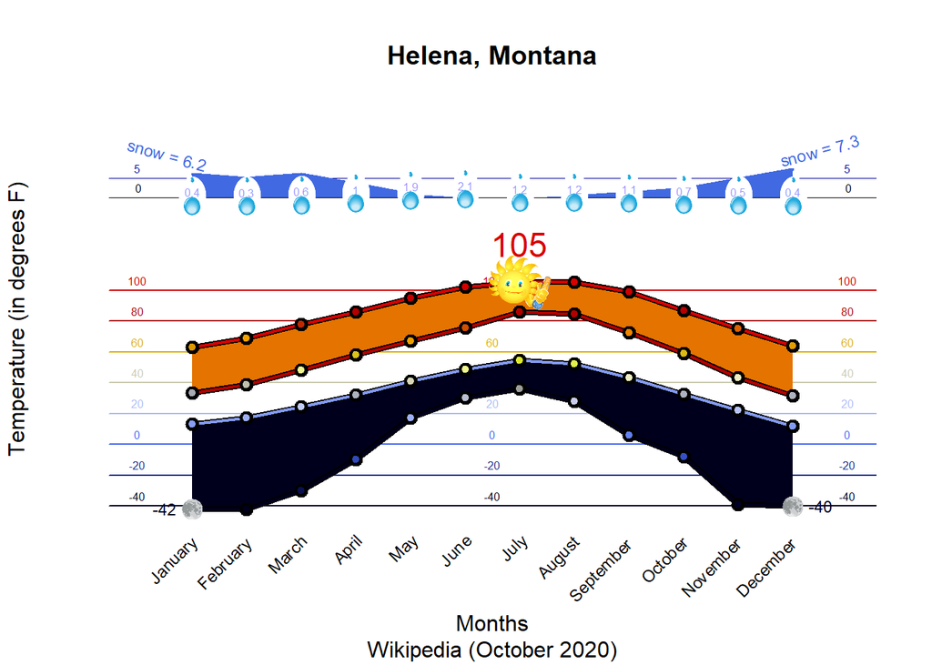

```r
climate = utils::read.csv( paste0(path.mshaffer, "_data_/state-capitals/final/state-capitals-climatedata.txt"), header=TRUE, quote="", sep="|");


plotTemperatureFromWikipediaData(climate, city.key="capital", city.val="Helena");
```

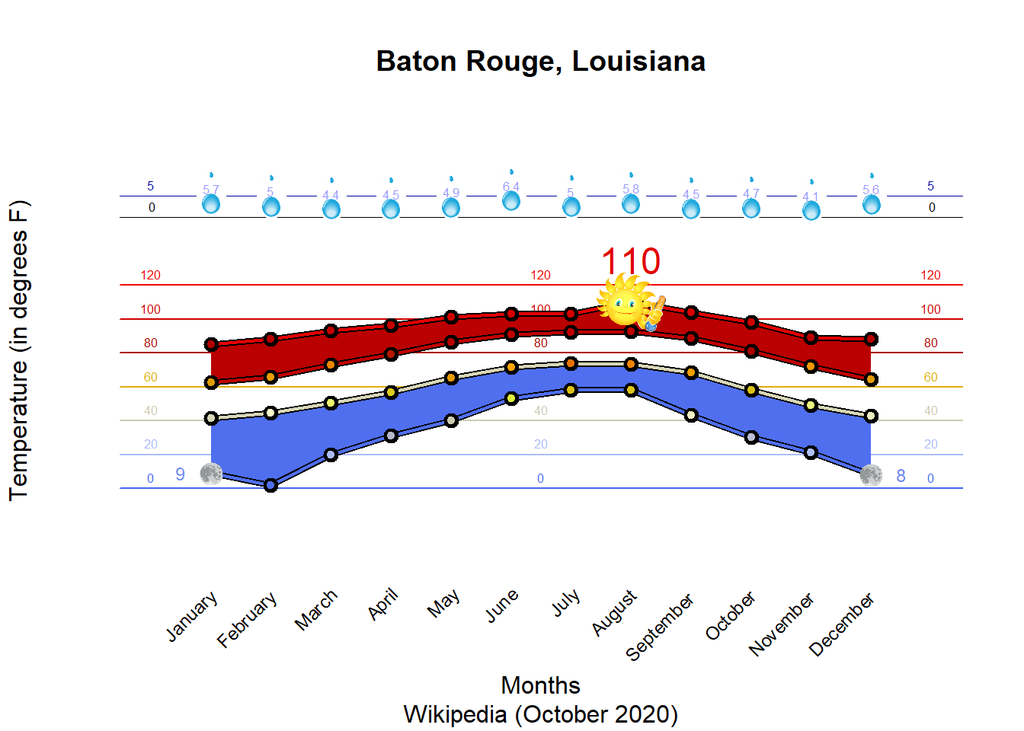

[output not shown]

```r
plotTemperatureFromWikipediaData(climate, city.key="capital", city.val="Baton Rouge");
```

[ What do you like about this graphic?

What do you dislike?

Is it aesthetically pleasing? Is it functional?

]

We can achieve a side-by-side comparison using the function described below. The first city will be graphed on the left, the second city on the right.

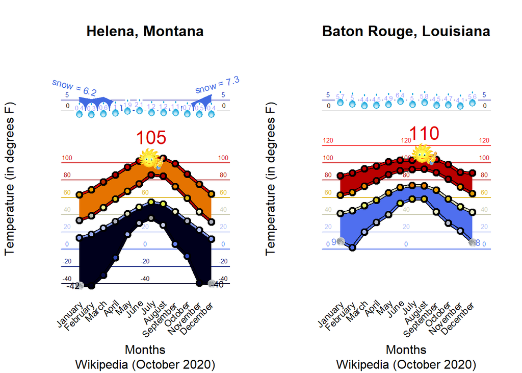

[output not shown]

```r
compareTwoCitiesClimates(climate, city.key="capital", city.1="Helena", city.2="Baton Rouge");
```

[ What do you like about this graphic?

What do you dislike?

Are the y-axis the same scale? Are the visible gridlines for each the same?

What is the difference between rain and snow on the graphic? Was that a good approach? How would you have done it?

]

##### (5 points) One Publication Graph

We are in exploration, so the “one” research graphic may be very different than the “one” formal graphic designed for a client. Typically, the final graphic needs to meet certain criteria:

- Very pleasing aesthetically
- Interactive if possible
- Live data feeds if possible
- Served in a secure, safe, private location (if required by the client)

To demonstrate the differences, I created a mockup of our 50 U.S. cities and put it into a nice finalized product form called “highcharts”.

http://md5.mshaffer.com/WSU_STATS419/_EXAMPLES_/fiddle_usmap/

It pulls data in real time (using AJAX) to grab the weather at the latitudes/longitudes we defined in our Wikipedia notebook.

- You can use your mouse to draw a box to zoom in.
- The third-wheel on the mouse also helps you zoom in/out.
- Hold down CNTRL with your left hand and use your mouse key to drag the map. It seems to only “pan” in the x-direction at the moment.
- The data in the popup displayed can be customized. I report the temperature in Celsius/Fahrenheit and also display the population data we gathered from Wikipedia.

Once you have a template built, it is rather easy to modify it. Here I changed the background map, and all of the data/features stay the same:

http://md5.mshaffer.com/WSU_STATS419/_EXAMPLES_/fiddle_usmap/world.html

### Which Features to Include in the Analysis

- months, you can pick all of them `1:12` or maybe just one month per season (April, July, October, January)
- X, depending on what you chose for months, you can now select what climate columns you want to use
  - Some of Temperature Data
  - All of Temperature Data
  - Precipitation Data
  - Everything (All of Temperature Data, Precipitation Data)

If we want to cluster cities, which decisions seem best? Why? As you can see from the code below, you just comment out two options, and can quickly rerun the analysis.

- WHICH MONTHS
- WHICH COLUMNS

#### WHICH MONTHS & WHICH COLUMNS

```r
climate = utils::read.csv( paste0(path.mshaffer, "_data_/state-capitals/final/state-capitals-climatedata.txt"), header=TRUE, quote="", sep="|");

##################### WHICH MONTHS #####################
########################################################
months = 1:12; # all the data
#months = c(1,4,7,10); # one month of each of the four seasons
########################################################


month.abb;  # ?month.abb
```

```
##  [1] "Jan" "Feb" "Mar" "Apr" "May" "Jun" "Jul" "Aug" "Sep" "Oct" "Nov" "Dec"
```

```r
month.name;
```

```
##  [1] "January"   "February"  "March"     "April"     "May"       "June"
##  [7] "July"      "August"    "September" "October"   "November"  "December"
```

```r
month.name[months];  # these are the names of the months you are selecting ...
```

```
##  [1] "January"   "February"  "March"     "April"     "May"       "June"
##  [7] "July"      "August"    "September" "October"   "November"  "December"
```

```r
# this function would allow us to use different months as criteria and different climate-data keys.  It is variadic and flexible.  `key.n` are the names we will use for our new columns ...

climate.df = buildClimateDataFrame(climate, months, keys=c("Record high F (C)", "Average high F (C)", "Average low F (C)", "Record low F (C)", "Average precipitation inches (mm)", "Average snowfall inches (cm)"), keys.n = c("highmax", "highavg",  "lowavg", "lowmin", "rain", "snow") );

climate.df;
```

|  | state | capital | st | labels | highmax.Jan | highmax.Feb | highmax.Mar | highmax.Apr | highmax.May | highmax.Jun | highmax.Jul | highmax.Aug | highmax.Sep | highmax.Oct | highmax.Nov | highmax.Dec | highavg.Jan | highavg.Feb | highavg.Mar | highavg.Apr | highavg.May | highavg.Jun | highavg.Jul | highavg.Aug | highavg.Sep | highavg.Oct | highavg.Nov | highavg.Dec | lowavg.Jan | … |
| --- | --- | --- | --- | --- | --- | --- | --- | --- | --- | --- | --- | --- | --- | --- | --- | --- | --- | --- | --- | --- | --- | --- | --- | --- | --- | --- | --- | --- | --- | --- |
| 1 | Alabama | Montgomery | AL | Montgomery, AL | 83 | 86 | 90 | 94 | 99 | 106 | 107 | 106 | 106 | 102 | 91 | 85 | 57.4 | 61.8 | 69.7 | 76.6 | 84.0 | 89.8 | 92.1 | 91.9 | 87.3 | 78.3 | 69.0 | 59.6 | 35.7 | … |
| 23 | Alaska | Juneau | AK | Juneau, AK | 60 | 57 | 61 | 72 | 80 | 87 | 89 | 87 | 85 | 68 | 64 | 59 | 34.6 | 36.7 | 40.8 | 49.1 | 56.9 | 62.4 | 63.4 | 62.6 | 56.6 | 48.4 | 39.8 | 36.7 | 26.2 | … |
| 39 | Arizona | Phoenix | AZ | Phoenix, AZ | 88 | 92 | 100 | 105 | 114 | 122 | 121 | 117 | 116 | 107 | 96 | 87 | 67.2 | 70.7 | 76.9 | 85.2 | 94.8 | 103.9 | 106.1 | 104.4 | 99.8 | 88.5 | 75.5 | 66.0 | 45.6 | … |
| 59 | Arkansas | Little Rock | AR | Little Rock, AR | 83 | 87 | 91 | 95 | 98 | 107 | 112 | 114 | 106 | 98 | 86 | 81 | 50.5 | 55.1 | 64.0 | 73.1 | 81.1 | 88.9 | 92.5 | 92.6 | 85.6 | 74.8 | 63.0 | 52.3 | 31.2 | … |
| 79 | California | Sacramento | CA | Sacramento, CA | 79 | 80 | 90 | 98 | 107 | 112 | 114 | 112 | 109 | 102 | 86 | 72 | 54.4 | 61.2 | 66.8 | 72.7 | 80.9 | 87.9 | 93.3 | 92.2 | 87.9 | 77.9 | 63.7 | 54.3 | 40.7 | … |
| 94 | Colorado | Denver | CO | Denver, CO | 76 | 80 | 84 | 90 | 95 | 105 | 105 | 105 | 101 | 90 | 81 | 79 | 44.0 | 46.2 | 54.4 | 61.5 | 71.5 | 82.4 | 89.4 | 87.2 | 78.5 | 65.3 | 52.1 | 42.8 | 17.4 | … |
| 117 | Connecticut | Hartford | CT | Hartford, CT | 72 | 77 | 89 | 96 | 99 | 100 | 103 | 102 | 101 | 91 | 83 | 76 | 34.5 | 38.5 | 47.7 | 60.5 | 71.2 | 79.6 | 84.5 | 82.7 | 74.9 | 63.1 | 51.6 | 39.7 | 17.7 | … |
| 141 | Delaware | Dover | DE | Dover, DE | 77 | 80 | 88 | 97 | 98 | 101 | 104 | 102 | 99 | 95 | 85 | 75 | 43.4 | 47.0 | 54.9 | 65.7 | 74.7 | 83.2 | 87.0 | 85.2 | 79.3 | 68.8 | 58.5 | 47.4 | 27.1 | … |
| 162 | Florida | Tallahassee | FL | Tallahassee, FL | 83 | 89 | 91 | 95 | 102 | 105 | 104 | 103 | 102 | 95 | 89 | 84 | 63.5 | 67.5 | 73.8 | 79.9 | 87.0 | 91.0 | 92.1 | 91.5 | 88.4 | 81.4 | 73.0 | 65.3 | 39.0 | … |
| 182 | Georgia | Atlanta | GA | Atlanta, GA | 79 | 80 | 89 | 93 | 97 | 106 | 105 | 104 | 102 | 98 | 84 | 79 | 52.3 | 56.6 | 64.6 | 72.5 | 79.9 | 86.4 | 89.1 | 88.1 | 82.2 | 72.7 | 63.6 | 54.0 | 34.3 | … |

[output cut: 40 more lines]

```r
names(climate.df); # this helps you see the indexes ...
```

```
##  [1] "state"       "capital"     "st"          "labels"      "highmax.Jan"
##  [6] "highmax.Feb" "highmax.Mar" "highmax.Apr" "highmax.May" "highmax.Jun"
## [11] "highmax.Jul" "highmax.Aug" "highmax.Sep" "highmax.Oct" "highmax.Nov"
## [16] "highmax.Dec" "highavg.Jan" "highavg.Feb" "highavg.Mar" "highavg.Apr"
## [21] "highavg.May" "highavg.Jun" "highavg.Jul" "highavg.Aug" "highavg.Sep"
## [26] "highavg.Oct" "highavg.Nov" "highavg.Dec" "lowavg.Jan"  "lowavg.Feb"
## [31] "lowavg.Mar"  "lowavg.Apr"  "lowavg.May"  "lowavg.Jun"  "lowavg.Jul"
## [36] "lowavg.Aug"  "lowavg.Sep"  "lowavg.Oct"  "lowavg.Nov"  "lowavg.Dec"
## [41] "lowmin.Jan"  "lowmin.Feb"  "lowmin.Mar"  "lowmin.Apr"  "lowmin.May"
## [46] "lowmin.Jun"  "lowmin.Jul"  "lowmin.Aug"  "lowmin.Sep"  "lowmin.Oct"
## [51] "lowmin.Nov"  "lowmin.Dec"  "rain.Jan"    "rain.Feb"    "rain.Mar"
## [56] "rain.Apr"    "rain.May"    "rain.Jun"    "rain.Jul"    "rain.Aug"
## [61] "rain.Sep"    "rain.Oct"    "rain.Nov"    "rain.Dec"    "snow.Jan"
## [66] "snow.Feb"    "snow.Mar"    "snow.Apr"    "snow.May"    "snow.Jun"
## [71] "snow.Jul"    "snow.Aug"    "snow.Sep"    "snow.Oct"    "snow.Nov"
## [76] "snow.Dec"
```

```r
##################### WHICH COLUMNS #####################
########################################################
#X = climate.df[,5:52];  # temperature
X = climate.df[,5:76];  # everything (includes rain)
#X = climate.df[,5:20];  # temperature, 1 month per season
#X = climate.df[,5:28];  # everything (includes rain), 1 month per season
########################################################


  rownames(X) = climate.df$labels;
Xs = scale(X);
```

### To scale or not to scale, that is the question

```r
X = climate.df[,5:76];  # everything ... you have to change months above to get this dataframe to be the correct size ... months = 1:12
  rownames(X) = climate.df$labels;
Xs = scale(X);
```

So let’s do some analysis with all of the data available to us. Most of the data is in Temperature, with ranges from -42 degrees Fahrenheit (Helena, Montana) to 122 (Phoenix, Arizona).

The precipitation data (rain and snow) is measured in inches. So should we scale the data. The answer in PCA and orthogonal projections is absolutely YES, but for `hclust` and `kmeans` is that always the case?

You can make a choice below, and observe how it influences your answers.

#### WHICH X

```r
whichX = X;
# whichX = Xs;
```

### Perform `k-means` on All Climate Features

With the selected features let’s perform k-means. Let’s select k=12. I will select all of the features, but you can change that if you wish.

#### Descriptives of Sample

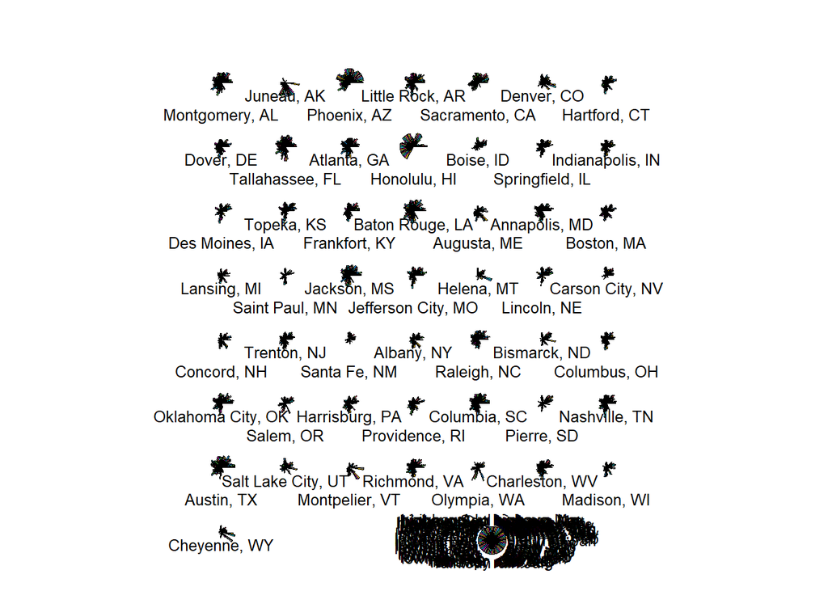

```r
colors = rainbow(50, s = 0.6, v = 0.75); # 50 colors for 50 states

# descriptive star plot to start
stars(whichX, len = 0.5, key.loc=c(12,2), draw.segments = TRUE);
```

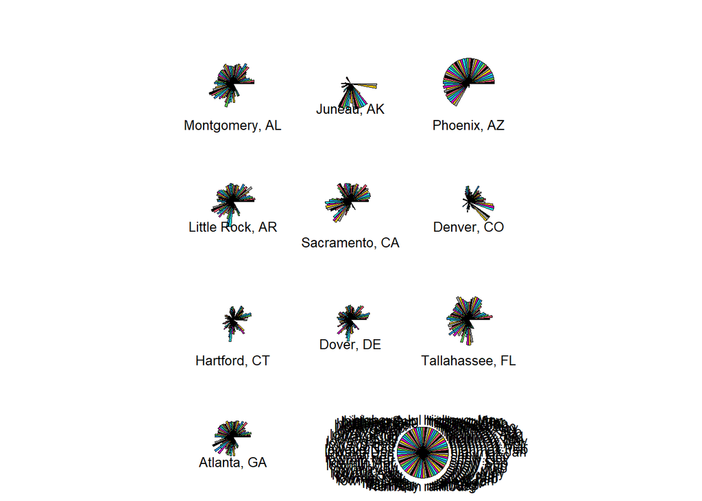

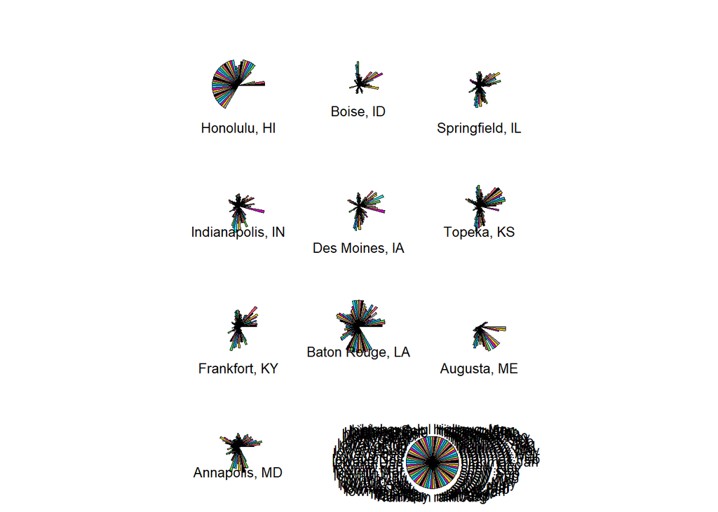

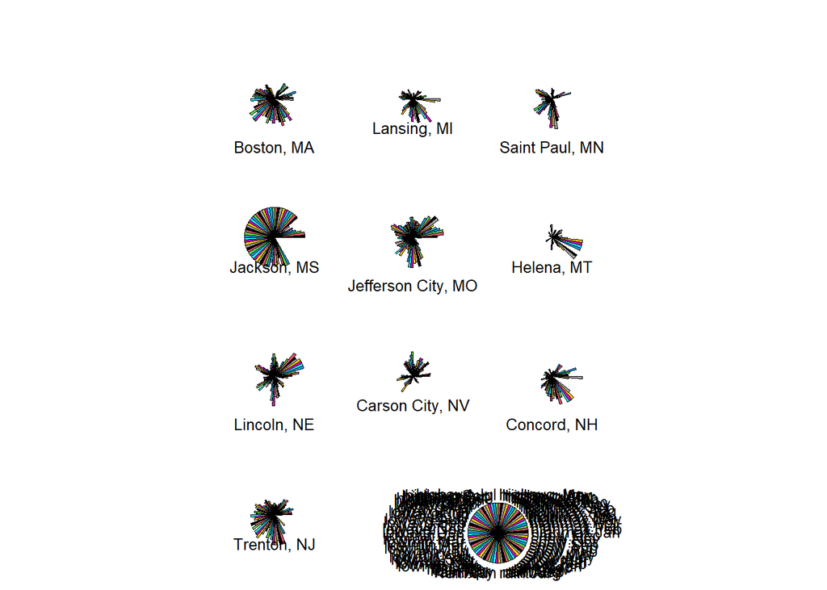

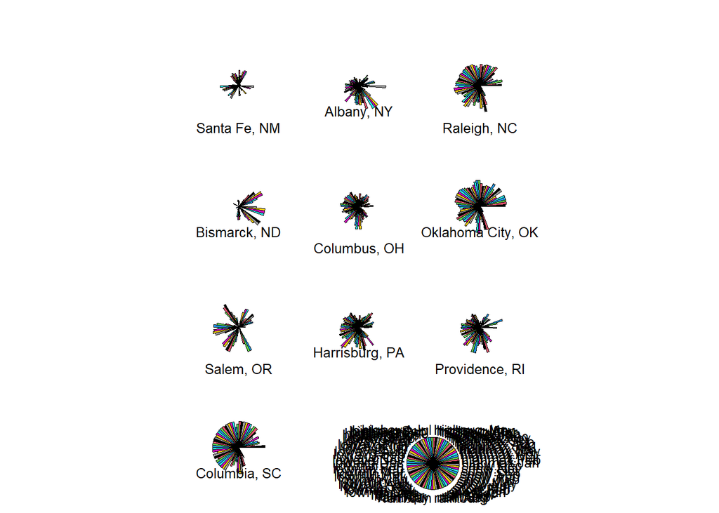

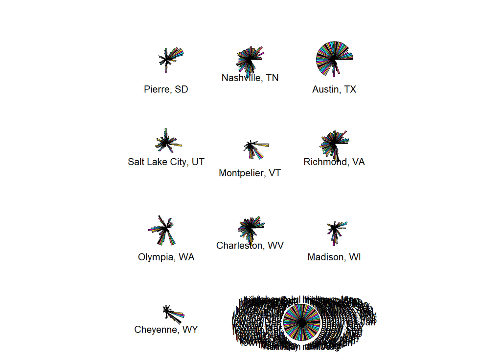

```r
## too busy, let's group them
x.start = 1;
x.end = 10;
for(i in 1:5)
  {
  stars( whichX[x.start:x.end,] ,
          len = 0.5, key.loc=c(6,2), draw.segments = TRUE);
  x.start = 1 + x.end;
  x.end = 10 + x.end;
  }
```

Above, you are just analyzing the general shapes. Which ones are “fuller” circles? Why?

Which ones are not very “full circles”? Why?

#### Computation of Clusters/Centroids

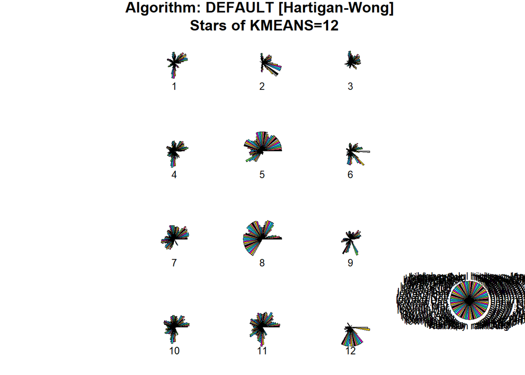

```r
k = 12;
iterations = 100;
number.starts = 100;

whichX.kmeans = kmeans(whichX, 12,
                    iter.max=iterations,
                    nstart = number.starts);  # default algorithm
stars(whichX.kmeans$centers, len = 0.5, key.loc = c(10, 3),
        main = "Algorithm: DEFAULT [Hartigan-Wong] \n Stars of KMEANS=12", draw.segments = TRUE);
```

#### Cluster Membership and Centroid Attributes

```r
membership = matrix( whichX.kmeans$cluster, ncol=1);
membership = membership[order(membership),];
membership = as.data.frame(membership);
        rownames(membership) = climate.df$labels;
        colnames(membership) = c("Cluster");

membership;
```

[output not shown]

[output cut: 40 more lines]

```r
print( table(membership) ) ;
```

```
## membership
##  1  2  3  4  5  6  7  8  9 10 11 12
##  4  3  5 12  1  6  1  1  2  8  6  1
```

```r
# I believe in an older version of R these were called $centroids
attributes = as.data.frame( whichX.kmeans$centers );
    rownames(attributes) = paste0("Cluster.",1:12);
  attributes;
```

|  | highmax.Jan | highmax.Feb | highmax.Mar | highmax.Apr | highmax.May | highmax.Jun | highmax.Jul | highmax.Aug | highmax.Sep | highmax.Oct | highmax.Nov | highmax.Dec | highavg.Jan | highavg.Feb | highavg.Mar | highavg.Apr | highavg.May | highavg.Jun | highavg.Jul | highavg.Aug | highavg.Sep | highavg.Oct | highavg.Nov | highavg.Dec | lowavg.Jan | lowavg.Feb | lowavg.Mar | lowavg.Apr | lowavg.May | … |
| --- | --- | --- | --- | --- | --- | --- | --- | --- | --- | --- | --- | --- | --- | --- | --- | --- | --- | --- | --- | --- | --- | --- | --- | --- | --- | --- | --- | --- | --- | --- |
| Cluster.1 | 66.25000 | 73.75000 | 88.25000 | 95.25000 | 101.75000 | 106.5000 | 111.7500 | 109.2500 | 102.50000 | 94.75000 | 82.25000 | 71.75000 | 30.60000 | 35.52500 | 47.42500 | 61.07500 | 71.95000 | 81.45000 | 87.12500 | 84.97500 | 76.07500 | 62.22500 | 46.07500 | 32.87500 | 11.22500 | 15.65000 | 26.27500 | 38.02500 | 49.60000 | … |
| Cluster.2 | 65.33333 | 71.00000 | 78.66667 | 87.66667 | 96.00000 | 104.3333 | 106.3333 | 104.0000 | 99.66667 | 89.00000 | 76.33333 | 66.33333 | 32.06667 | 35.80000 | 45.36667 | 56.56667 | 66.73333 | 76.06667 | 84.60000 | 83.06667 | 72.16667 | 58.33333 | 43.06667 | 32.03333 | 11.06667 | 14.46667 | 22.70000 | 31.20000 | 41.23333 | … |
| Cluster.3 | 67.80000 | 73.80000 | 80.80000 | 88.60000 | 96.80000 | 104.0000 | 106.2000 | 104.4000 | 100.00000 | 90.60000 | 77.60000 | 71.60000 | 41.58000 | 46.44000 | 55.06000 | 62.56000 | 72.12000 | 82.26000 | 89.74000 | 87.76000 | 78.92000 | 65.84000 | 51.44000 | 41.30000 | 20.58000 | 23.84000 | 30.08000 | 35.66000 | 43.76000 | … |
| Cluster.4 | 74.83333 | 78.66667 | 89.41667 | 94.00000 | 98.58333 | 102.7500 | 107.5833 | 105.6667 | 102.91667 | 93.83333 | 83.41667 | 76.50000 | 37.86667 | 42.00000 | 51.77500 | 63.13333 | 72.58333 | 81.28333 | 85.49167 | 84.21667 | 77.08333 | 65.65000 | 53.80833 | 41.65000 | 21.45000 | 24.45000 | 32.06667 | 41.79167 | 51.41667 | … |
| Cluster.5 | 88.00000 | 92.00000 | 100.00000 | 105.00000 | 114.00000 | 122.0000 | 121.0000 | 117.0000 | 116.00000 | 107.00000 | 96.00000 | 87.00000 | 67.20000 | 70.70000 | 76.90000 | 85.20000 | 94.80000 | 103.90000 | 106.10000 | 104.40000 | 99.80000 | 88.50000 | 75.50000 | 66.00000 | 45.60000 | 48.70000 | 53.50000 | 60.20000 | 69.40000 | … |
| Cluster.6 | 65.66667 | 67.66667 | 85.50000 | 91.66667 | 96.00000 | 99.0000 | 102.0000 | 100.6667 | 97.33333 | 88.66667 | 78.00000 | 69.00000 | 28.65000 | 32.66667 | 42.46667 | 56.20000 | 67.73333 | 76.61667 | 81.05000 | 79.25000 | 71.26667 | 58.71667 | 46.01667 | 33.61667 | 11.80000 | 14.78333 | 23.55000 | 34.81667 | 44.83333 | … |
| Cluster.7 | 79.00000 | 80.00000 | 90.00000 | 98.00000 | 107.00000 | 112.0000 | 114.0000 | 112.0000 | 109.00000 | 102.00000 | 86.00000 | 72.00000 | 54.40000 | 61.20000 | 66.80000 | 72.70000 | 80.90000 | 87.90000 | 93.30000 | 92.20000 | 87.90000 | 77.90000 | 63.70000 | 54.30000 | 40.70000 | 43.70000 | 46.50000 | 49.00000 | 53.90000 | … |
| Cluster.8 | 88.00000 | 88.00000 | 89.00000 | 91.00000 | 93.00000 | 92.0000 | 94.0000 | 95.0000 | 95.00000 | 94.00000 | 93.00000 | 89.00000 | 80.10000 | 80.20000 | 81.20000 | 82.70000 | 84.60000 | 87.00000 | 87.90000 | 88.70000 | 88.60000 | 86.70000 | 83.90000 | 81.20000 | 66.30000 | 66.10000 | 67.70000 | 69.40000 | 70.90000 | … |
| Cluster.9 | 66.00000 | 72.50000 | 79.50000 | 90.50000 | 98.00000 | 101.5000 | 106.0000 | 106.0000 | 101.00000 | 91.50000 | 74.00000 | 68.00000 | 46.80000 | 50.45000 | 55.20000 | 60.00000 | 66.55000 | 72.25000 | 79.40000 | 80.05000 | 74.30000 | 62.15000 | 51.40000 | 45.20000 | 34.20000 | 33.70000 | 36.15000 | 38.65000 | 42.40000 | … |
| Cluster.10 | 79.75000 | 84.12500 | 91.75000 | 95.25000 | 98.75000 | 105.2500 | 106.6250 | 107.1250 | 103.25000 | 97.25000 | 86.12500 | 80.00000 | 47.97500 | 52.13750 | 60.56250 | 70.08750 | 78.06250 | 85.92500 | 89.68750 | 88.53750 | 81.80000 | 71.41250 | 61.10000 | 50.61250 | 29.77500 | 32.57500 | 39.53750 | 47.98750 | 57.33750 | … |

[output cut: 2 more lines]

#### (10 points) Summarize Findings

- Identify which states share a common cluster.
- For a given cluster, what are its primary characteristics

[output not shown]

[ Summarize your k-means findings for 12 clusters.]

## (15 points) Correlation

Correlation, like distance, is an important feature of multivariate analysis. So let’s review some basic correlation related to our climate data. For simplicity, let’s consider “Record High Temperature” and “Record Low Temperature” and see how they correlate with other factors we have gathered from Wikipedia.

Recall, in this table, “Jan-Dec” are different months of the same temperature variable.

```r
library(Hmisc); # p-values for correlation
high = subsetDataFrame(climate, c("key", "units"), "==", c("Record high F (C)",1));
high = merge(high, capitals, by=c("capital","state"));

high.X = high[,c(5:18,21)]; # numeric data
high.cor = round( cor(high.X), digits=2);
# high.cor.p = rcorr(as.matrix(high.X), type="pearson");  # p-values for statistical significance ... # str(high.cor.p);

# examine July (idx = 7)

as.data.frame( high.cor ) ; # so it will render nicely in RStudio
```

|  | Jan | Feb | Mar | Apr | May | Jun | Jul | Aug | Sep | Oct | Nov | Dec | latitude | longitude | population.2019.est |
| --- | --- | --- | --- | --- | --- | --- | --- | --- | --- | --- | --- | --- | --- | --- | --- |
| Jan | 1.00 | 0.92 | 0.76 | 0.57 | 0.43 | 0.39 | 0.25 | 0.41 | 0.62 | 0.71 | 0.89 | 0.94 | -0.83 | 0.07 | 0.40 |
| Feb | 0.92 | 1.00 | 0.80 | 0.63 | 0.62 | 0.53 | 0.45 | 0.59 | 0.74 | 0.79 | 0.89 | 0.89 | -0.80 | 0.01 | 0.42 |
| Mar | 0.76 | 0.80 | 1.00 | 0.87 | 0.73 | 0.56 | 0.53 | 0.67 | 0.76 | 0.82 | 0.89 | 0.81 | -0.68 | 0.39 | 0.36 |
| Apr | 0.57 | 0.63 | 0.87 | 1.00 | 0.82 | 0.68 | 0.65 | 0.75 | 0.79 | 0.81 | 0.76 | 0.65 | -0.49 | 0.34 | 0.35 |
| May | 0.43 | 0.62 | 0.73 | 0.82 | 1.00 | 0.83 | 0.85 | 0.85 | 0.86 | 0.81 | 0.65 | 0.46 | -0.40 | 0.08 | 0.38 |
| Jun | 0.39 | 0.53 | 0.56 | 0.68 | 0.83 | 1.00 | 0.90 | 0.86 | 0.87 | 0.78 | 0.56 | 0.41 | -0.30 | 0.01 | 0.48 |
| Jul | 0.25 | 0.45 | 0.53 | 0.65 | 0.85 | 0.90 | 1.00 | 0.91 | 0.86 | 0.73 | 0.46 | 0.27 | -0.15 | 0.02 | 0.31 |
| Aug | 0.41 | 0.59 | 0.67 | 0.75 | 0.85 | 0.86 | 0.91 | 1.00 | 0.90 | 0.78 | 0.57 | 0.46 | -0.29 | 0.04 | 0.31 |
| Sep | 0.62 | 0.74 | 0.76 | 0.79 | 0.86 | 0.87 | 0.86 | 0.90 | 1.00 | 0.88 | 0.74 | 0.65 | -0.46 | 0.07 | 0.44 |
| Oct | 0.71 | 0.79 | 0.82 | 0.81 | 0.81 | 0.78 | 0.73 | 0.78 | 0.88 | 1.00 | 0.86 | 0.72 | -0.67 | 0.14 | 0.39 |

[output cut: 5 more lines]

```r
high.cor.july = high.cor[,7];
high.cor.july;
```

```
##                 Jan                 Feb                 Mar                 Apr
##                0.25                0.45                0.53                0.65
##                 May                 Jun                 Jul                 Aug
##                0.85                0.90                1.00                0.91
##                 Sep                 Oct                 Nov                 Dec
##                0.86                0.73                0.46                0.27
##            latitude           longitude population.2019.est
##               -0.15                0.02                0.31
```

[output not shown]

Describe the correlation of July in “Record high F (C)” to the other numeric factors printed above.

**x is correlated with y (0.00). This correlation is positive/negative which means … This correlation is strong/weak because … overall, this suggests …**

- July perfectly correlates with July (1.00). This correlation is positive and very strong. This is because they are the same data.
- With the months, you can note each, or plot a trend showing them, and discussing them briefly as a trend.
- latitude is a measure of north/south, so be certain to apply the correlation value with some meaning. be certain you know which direction is positive or negative to correctly interpret the sign of the correlation.
- longitude is a measure of east/west, so be certain …
- population is the size of the city
- intuitively, which months do you think correlate most with latitude for this data? which correlate the least? is the correlation always the same sign (positive/negative), or does it change? [You can use the dataframe output to do this analysis, or create your own subset]

```r
library(Hmisc); # p-values for correlation

low = subsetDataFrame(climate, c("key", "units"), "==", c("Record low F (C)",1));
low = merge(low, capitals, by=c("capital","state"));

low.X = low[,c(5:18,21)]; # numeric data
low.cor = round( cor(low.X), digits=2);
# low.cor.p = rcorr(as.matrix(low.X), type="pearson");  # p-values for statistical significance ... # str(low.cor.p);

# examine Jan (idx = 1)

as.data.frame( low.cor ) ; # so it will render nicely in RStudio
```

|  | Jan | Feb | Mar | Apr | May | Jun | Jul | Aug | Sep | Oct | Nov | Dec | latitude | longitude | population.2019.est |
| --- | --- | --- | --- | --- | --- | --- | --- | --- | --- | --- | --- | --- | --- | --- | --- |
| Jan | 1.00 | 0.95 | 0.93 | 0.92 | 0.89 | 0.80 | 0.74 | 0.77 | 0.90 | 0.87 | 0.91 | 0.97 | -0.72 | -0.33 | 0.34 |
| Feb | 0.95 | 1.00 | 0.94 | 0.92 | 0.86 | 0.75 | 0.70 | 0.72 | 0.88 | 0.86 | 0.92 | 0.95 | -0.64 | -0.36 | 0.37 |
| Mar | 0.93 | 0.94 | 1.00 | 0.92 | 0.85 | 0.73 | 0.71 | 0.72 | 0.85 | 0.85 | 0.90 | 0.93 | -0.69 | -0.31 | 0.32 |
| Apr | 0.92 | 0.92 | 0.92 | 1.00 | 0.91 | 0.82 | 0.78 | 0.81 | 0.93 | 0.89 | 0.89 | 0.92 | -0.71 | -0.25 | 0.37 |
| May | 0.89 | 0.86 | 0.85 | 0.91 | 1.00 | 0.93 | 0.88 | 0.88 | 0.95 | 0.93 | 0.89 | 0.91 | -0.72 | -0.12 | 0.35 |
| Jun | 0.80 | 0.75 | 0.73 | 0.82 | 0.93 | 1.00 | 0.92 | 0.91 | 0.88 | 0.82 | 0.81 | 0.82 | -0.75 | -0.05 | 0.39 |
| Jul | 0.74 | 0.70 | 0.71 | 0.78 | 0.88 | 0.92 | 1.00 | 0.96 | 0.87 | 0.77 | 0.75 | 0.78 | -0.75 | 0.09 | 0.46 |
| Aug | 0.77 | 0.72 | 0.72 | 0.81 | 0.88 | 0.91 | 0.96 | 1.00 | 0.87 | 0.77 | 0.75 | 0.79 | -0.80 | 0.02 | 0.46 |
| Sep | 0.90 | 0.88 | 0.85 | 0.93 | 0.95 | 0.88 | 0.87 | 0.87 | 1.00 | 0.94 | 0.92 | 0.91 | -0.72 | -0.09 | 0.40 |
| Oct | 0.87 | 0.86 | 0.85 | 0.89 | 0.93 | 0.82 | 0.77 | 0.77 | 0.94 | 1.00 | 0.93 | 0.90 | -0.66 | -0.04 | 0.32 |

[output cut: 5 more lines]

```r
low.cor.january = low.cor[,1];
low.cor.january;
```

```
##                 Jan                 Feb                 Mar                 Apr
##                1.00                0.95                0.93                0.92
##                 May                 Jun                 Jul                 Aug
##                0.89                0.80                0.74                0.77
##                 Sep                 Oct                 Nov                 Dec
##                0.90                0.87                0.91                0.97
##            latitude           longitude population.2019.est
##               -0.72               -0.33                0.34
```

Describe the correlation of January in “Record low F (C)” to the other numeric factors printed above.

[output not shown]

Similar to “high” writeup, but for the “low” data.

## “So What” is DATA ANALYSIS?

In the social sciences (e.g., Karl Weick), the concept of “sense making” refers to “the process by which people give meaning to their collective experiences”. I have used this framework in my high-technology innovation research (See Figure 1 of http://www.mshaffer.com/arizona/pdf/LoneGenius.pdf, my rubric concept comes from learning-theory growth models: Nascent, Adolescent, Mature.)

This final topic is reflective: we are thinking about how we think.

### Statistics

The syllabus defined statistics as “the discipline that concerns the collection, organization, analysis, interpretation and presentation of data.” (See https://en.wikipedia.org/wiki/Statistics)

There are 5 elements mentioned: collection, organization, analysis, interpretation, and presentation of “data”. Are those equally weighted? That is, should we devote 20% of our time to each of those? Now, consider the “analysis” stage. I have suggested there are two camps: exploratory and confirmatory data analysis. Are those equally weighted? That is, should we devote 50% of our time to each of those? Now, in an “equally-likely” scenario, we would have.

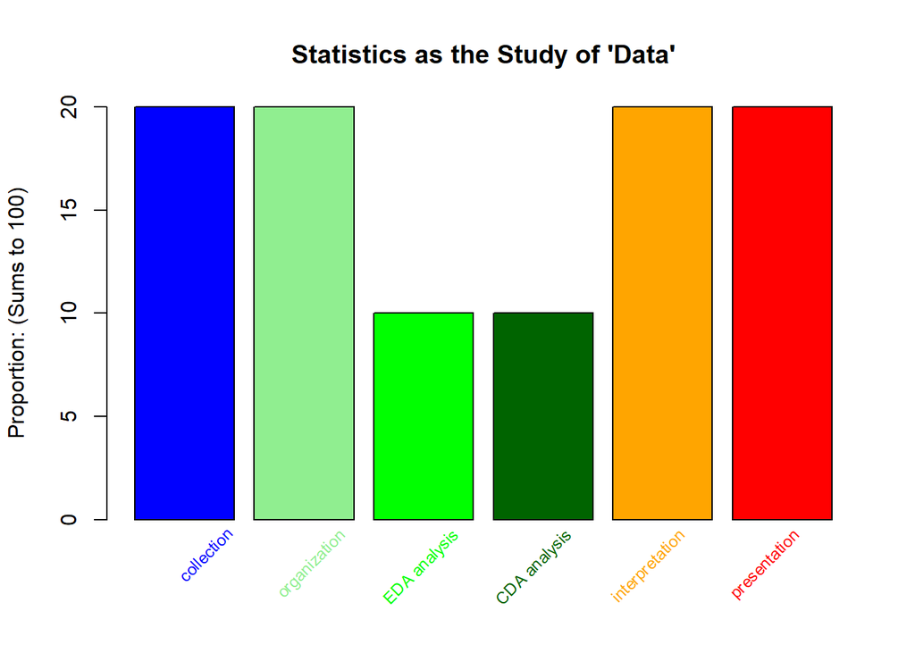

```r
x = c(20,20,10,10,20,20);
x.labels = c("collection", "organization", "EDA analysis", "CDA analysis", "interpretation", "presentation");
x.colors = c("blue", "lightgreen", "green", "darkgreen", "orange", "red");

barplot(x,
        col = x.colors,
        ylim = c(0, 20),
        ylab = "Proportion: (Sums to 100)",
        main="Statistics as the Study of 'Data'");


text(1.14* (1:6), par("usr")[3], col = x.colors, labels = x.labels, srt = 45, adj = c(1.1,1.1), xpd = TRUE, cex=.75);
```

### Data Analytics

[figure not shown]

**Source: https://data-analytics.wsu.edu/197-2/** (Accessed October 2010)

“Data analytics is the application of powerful new methods—drawn from computer science, mathematics and statistics, and domain sciences—to collect, curate, analyze, discover and communicate knowledge from ‘big data’.” https://data-analytics.wsu.edu/ (Accessed October 2010)

#### Importance of ‘Data’

I love data.

I also love math/physics. I also love exploratory data analysis. I also love computational statistics or statistical computing https://en.wikipedia.org/wiki/Computational_statistics. I also love thinking about developing the one graphic to summarize data most effectively.

#### Apprenticeship as Learning a Trade

The idea of sharing in the learning process is an important aspect of the apprenticeship model. You are learning a trade (data analytics). I have experience in this trade. My job as the instructor is to provide you with a variety of “situated-learning” experiences To help you understand the nature of the trade. This exam is an example of such an experience.

#### Tools of the Trade

Below are the core requirements for the data analytics program:

- Calculus and linear algebra (10 credits)
- Computer science fundamentals (11 credits)
- Machine learning and data management (9 credits)
- Statistics (15 credits)
- Data analytics introduction, ethics & project-focused * capstone experience (9 credits)

These are not the tools of the trade, but hopefully, they introduce you to key tools of the trade. What exactly are tools of the trade? [You will have an opportunity to write a response below.]

#### Dimensional Reduction, an Axiomatic View

This video was recently shared with me that highlights some distinctions among persons practicing various forms of data analysis https://www.youtube.com/watch?v=uHGlCi9jOWY. As an orthogonal projection, I would create two axes. On the horizontal axis (x-axis), I would place “theory of data” to the left and “application of data” toward the right. On the vertical axis (y-axis), I would place “care for data integrity” at the top and “less care for data integrity” at the bottom.

#### Skills of the Trade

As someone that is coming from industry, having hired young people like you out of Computer Science, Electrical-Computer Engineering, I have opinions related to skills of the trade.

- Can you acquire an appreciation for “data intimacy”?
- Can you track and document how data is curated?
- Can you track and document the analyses you perform? Can you recreate them? Do you have basic version-control protocols in place?
- Can you view data from multiple perspectives and synthesize those perspectives to identify the central them of the data? Can you be objective? Can you try and identify objective metrics to enlighten your understanding about the essence of data?
- Can you experiment with different visualizations in search of an optimal “one graphic” result? Do you have practice using various visualization tools? Can you comprehend which visualization tool is appropriate for messaging (communicating results) to a particular audience?
- Can you communicate and defend your findings to a particular audience? Are your communications professional? Is the final work product both simple and comprehensive: simple in its summary findings and comprehensive in its ability to be replicated and audited as necessary.

## (20 points) YOUR OPINION OF DATA ANALYTICS

[This is worth 20 points.

Specifically, address:

1. what proportion of “statistics” should be divided among: collection, organization, analysis, interpretation, and presentation of “data” … providing a `barplot` of your opinion within your response would seem appropriate

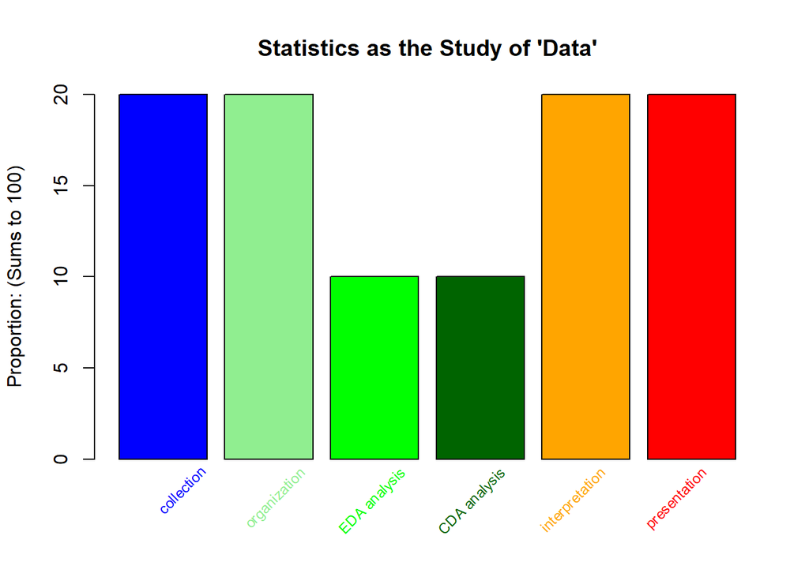

```r
x = c(20,20,10,10,20,20);  ## change these values and discuss ...
x.labels = c("collection", "organization", "EDA analysis", "CDA analysis", "interpretation", "presentation");
x.colors = c("blue", "lightgreen", "green", "darkgreen", "orange", "red");

barplot(x,
        col = x.colors,
        ylim = c(0, max(x)),
        ylab = "Proportion: (Sums to 100)",
        main="Statistics as the Study of 'Data'");


text(1.14* (1:6), par("usr")[3], col = x.colors, labels = x.labels, srt = 45, adj = c(1.1,1.1), xpd = TRUE, cex=.75);
```

2. what tools of the trade should you be acquiring from the core courses? how are you doing in that acquisition process (e.g., tool X is … and right now I feel like my understanding/proficiency of tool X … ) …
3. utilize the provided `plot` script to place the coure-course categories on the proposed x-y graph related to analytics practice (Applied vs Theoretical) and care of data integrity (Great Care vs Little Care) … Also place your personal assessment on the plot script provided
4. evaluate your skill-level on the six “skills of the trade”: Emerging (Nascent), Developing (Adolescent), Mastering (Mature). explain your evaluation and include other important skills you believe are relevant that are not included
5. Any other comments you would like to share.

]

[output not shown]

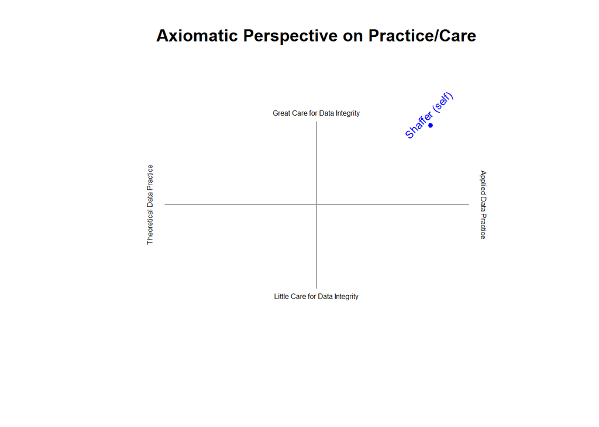

```r
# x is -1 for perfectly theoretical
# x is 1 for perfectly applied

# y is -1 for no care whatsoever for data integrity
# y is 1 is perfect care for data integrity

########################### basic plot setup #####
plot(0,0, col="white",
  ylim=c(-1.5,1.5), xlim=c(-1.5,1.5),
  xlab = "",
  ylab = "",
  xaxt = 'n', bty = 'n', yaxt = 'n',
  main = "Axiomatic Perspective on Practice/Care",
  );
segments(-1,0,1,0, col="#999999");
segments(0,-1,0,1, col="#999999");
text(-1.1,0, "Theoretical Data Practice", cex=0.5, srt = 90);
text(1.1,0, "Applied Data Practice", cex=0.5, srt = -90);
text(0,1.1, "Great Care for Data Integrity", cex=0.5, srt = 0);
text(0,-1.1, "Little Care for Data Integrity", cex=0.5, srt = 0);
########################### basic plot setup #####


########################### you can add elements here #####
## this point represents the professor's self-perception
points(0.75, 0.95, pch=20, col="blue");
text(0.75, 0.95, "Shaffer (self)", col="blue", cex=0.75, srt = 45, pos=3);
```

```r
#############  TODO ###### ... maybe change color for each data point

# https://brand.wsu.edu/visual/colors/
# crimson = #981e32
# you need to change the x,y from 0,0 ...
# you can change col ... cex (font size), srt (angle), and pos = 1,2,3,4
#
# points(0, 0, pch=20, col="#981e32");
# text(0, 0, "Student (self)", col="#981e32", cex=0.75, srt = 45, pos=3);
#
# ## evaluate the Course Categories of Tools of the Trade
# ## give them a score
#
# points(0, 0, pch=20, col="#981e32");
# text(0, 0, "Math(s)", col="#981e32", cex=0.5, srt = 45, pos=3);
#
#
# points(0, 0, pch=20, col="#981e32");
# text(0, 0, "Computer Science", col="#981e32", cex=0.5, srt = 45, pos=3);
#
# points(0, 0, pch=20, col="#981e32");
# text(0, 0, "Machine learning", col="#981e32", cex=0.5, srt = 45, pos=3);
#
# points(0, 0, pch=20, col="#981e32");
# text(0, 0, "Statistics", col="#981e32", cex=0.5, srt = 45, pos=3);
#
# points(0, 0, pch=20, col="#981e32");
# text(0, 0, "Data analytics", col="#981e32", cex=0.5, srt = 45, pos=3);
#
# # You have a track (e.g., Business)
# points(0, 0, pch=20, col="#981e32");
# text(0, 0, "Core discipline", col="#981e32", cex=0.5, srt = 45, pos=3);
```